# Ford GoBike Data Exploration

## Introduction

> A bike-share system is a service in which bicycles are made available for shared use to individuals on a short term basis for a price or free. Many bike share systems allow people to borrow a bike from a "dock" and return it at another dock belonging to the same system. Ford GoBike is a public bicycle sharing system in San Francisco Bay Area, California. currently has over 2,600 bicycles in 262 stations across San Francisco, East Bay and San Jose. As of January 2018, the system had seen nearly 500,000 rides since the launch in 2017 and had about 10,000 annual subscribers.

## Preliminary Wrangling

In this project, we are analyzing data from 2017 to July 2019.

```python
# import all packages and set plots to be embedded inline.

import pandas as pd
import numpy as np
import requests
import zipfile
import os
import glob
from io import BytesIO
import datetime
from math import sin, cos, atan2, sqrt, radians
import matplotlib.pyplot as plt
import seaborn as sns
sns.set_style("darkgrid")
%matplotlib inline
```

## Gather

File for data of 2017 is in csv format while the rest of the files are in csv format but zipped. Therefore, we are downloading them seperately. Here, I have created a folder 'extracted_csvs' which will contain all the downloaded files.

```python
folder_name = "extracted_csvs"
if not os.path.exists(folder_name):
    os.makedirs(folder_name)

url = "https://s3.amazonaws.com/baywheels-data/2017-fordgobike-tripdata.csv"
response = requests.get(url)
with open(os.path.join(folder_name,"2017-fordgobike-tripdata.csv"), mode='wb') as file:
    file.write(response.content)
df = pd.read_csv("./extracted_csvs/2017-fordgobike-tripdata.csv")
df.head()
```

|  | duration_sec | start_time | end_time | start_station_id | start_station_name | start_station_latitude | start_station_longitude | end_station_id | end_station_name | end_station_latitude | end_station_longitude | bike_id | user_type | member_birth_year | member_gender |
| --- | --- | --- | --- | --- | --- | --- | --- | --- | --- | --- | --- | --- | --- | --- | --- |
| 0 | 80110 | 2017-12-31 16:57:39.6540 | 2018-01-01 15:12:50.2450 | 74 | Laguna St at Hayes St | 37.776435 | -122.426244 | 43 | San Francisco Public Library (Grove St at Hyde... | 37.778768 | -122.415929 | 96 | Customer | 1987.0 | Male |
| 1 | 78800 | 2017-12-31 15:56:34.8420 | 2018-01-01 13:49:55.6170 | 284 | Yerba Buena Center for the Arts (Howard St at ... | 37.784872 | -122.400876 | 96 | Dolores St at 15th St | 37.766210 | -122.426614 | 88 | Customer | 1965.0 | Female |
| 2 | 45768 | 2017-12-31 22:45:48.4110 | 2018-01-01 11:28:36.8830 | 245 | Downtown Berkeley BART | 37.870348 | -122.267764 | 245 | Downtown Berkeley BART | 37.870348 | -122.267764 | 1094 | Customer | NaN | NaN |
| 3 | 62172 | 2017-12-31 17:31:10.6360 | 2018-01-01 10:47:23.5310 | 60 | 8th St at Ringold St | 37.774520 | -122.409449 | 5 | Powell St BART Station (Market St at 5th St) | 37.783899 | -122.408445 | 2831 | Customer | NaN | NaN |
| 4 | 43603 | 2017-12-31 14:23:14.0010 | 2018-01-01 02:29:57.5710 | 239 | Bancroft Way at Telegraph Ave | 37.868813 | -122.258764 | 247 | Fulton St at Bancroft Way | 37.867789 | -122.265896 | 3167 | Subscriber | 1997.0 | Female |

Downloading rest of the files from 2018 to July 2019 and extracting them in 'extracted_csvs' folder.

```python
url_frnt = "https://s3.amazonaws.com/baywheels-data/201"
url_list = list(range(801,813)) + list(range(901,908))
url_list1 = ['fordgobike']*16 + ['baywheels']*3
url_end = "-tripdata.csv.zip"

for str1,str2 in zip(url_list, url_list1):
    url = url_frnt + str(str1) + '-' + str2 + url_end
    response = requests.get(url)
    file = zipfile.ZipFile(BytesIO(response.content))
    file.extractall(folder_name)
```

Reading all the csv files in the 'extracted_csvs' folder and concat them together in one dataframe. Further saving it as 'bike_final_df.csv'

```python
files = glob.glob(os.path.join(folder_name, "*.csv"))
df_bike = pd.concat([pd.read_csv(f) for f in files], ignore_index = True)

df_bike.to_csv('bike_final_df.csv', index = False)
```

```python
df_bike.head()
```

|  | Unnamed: 16 | bike_id | bike_share_for_all_trip | duration_sec | end_station_id | end_station_latitude | end_station_longitude | end_station_name | end_time | member_birth_year | member_gender | rental_access_method | start_station_id | start_station_latitude | start_station_longitude | start_station_name | start_time | user_type |
| --- | --- | --- | --- | --- | --- | --- | --- | --- | --- | --- | --- | --- | --- | --- | --- | --- | --- | --- |
| 0 | NaN | 3458 | No | 80066 | 147.0 | 37.744067 | -122.421472 | 29th St at Tiffany Ave | 2018-11-01 19:03:30.0550 | 1987.0 | Female | NaN | 138.0 | 37.750900 | -122.427411 | Jersey St at Church St | 2018-10-31 20:49:03.1400 | Customer |
| 1 | NaN | 1798 | No | 56428 | 86.0 | 37.769305 | -122.426826 | Market St at Dolores St | 2018-11-01 11:58:31.1460 | NaN | NaN | NaN | 75.0 | 37.773793 | -122.421239 | Market St at Franklin St | 2018-10-31 20:18:02.8810 | Customer |
| 2 | NaN | 1575 | No | 44825 | 122.0 | 37.760299 | -122.418892 | 19th St at Mission St | 2018-11-01 08:34:19.3670 | 1983.0 | Female | NaN | 139.0 | 37.751017 | -122.411901 | Garfield Square (25th St at Harrison St) | 2018-10-31 20:07:13.3780 | Customer |
| 3 | NaN | 2978 | No | 55461 | 16.0 | 37.794130 | -122.394430 | Steuart St at Market St | 2018-11-01 08:30:59.2200 | 1992.0 | Female | NaN | 67.0 | 37.776639 | -122.395526 | San Francisco Caltrain Station 2 (Townsend St... | 2018-10-31 17:06:37.6830 | Subscriber |
| 4 | NaN | 2392 | No | 47724 | 259.0 | 37.866249 | -122.299371 | Addison St at Fourth St | 2018-11-01 07:43:01.5610 | NaN | NaN | NaN | 259.0 | 37.866249 | -122.299371 | Addison St at Fourth St | 2018-10-31 18:27:36.8230 | Customer |

```python
df_bike.info()
```

```
<class 'pandas.core.frame.DataFrame'>
RangeIndex: 3828132 entries, 0 to 3828131
Data columns (total 18 columns):
Unnamed: 16                object
bike_id                    int64
bike_share_for_all_trip    object
duration_sec               int64
end_station_id             float64
end_station_latitude       float64
end_station_longitude      float64
end_station_name           object
end_time                   object
member_birth_year          float64
member_gender              object
rental_access_method       object
start_station_id           float64
start_station_latitude     float64
start_station_longitude    float64
start_station_name         object
start_time                 object
user_type                  object
dtypes: float64(7), int64(2), object(9)
memory usage: 525.7+ MB
```

## Access

```python
df_bike = pd.read_csv('bike_final_df.csv', low_memory=False)
```

```python
df_bike.head()
```

|  | Unnamed: 16 | bike_id | bike_share_for_all_trip | duration_sec | end_station_id | end_station_latitude | end_station_longitude | end_station_name | end_time | member_birth_year | member_gender | rental_access_method | start_station_id | start_station_latitude | start_station_longitude | start_station_name | start_time | user_type |
| --- | --- | --- | --- | --- | --- | --- | --- | --- | --- | --- | --- | --- | --- | --- | --- | --- | --- | --- |
| 0 | NaN | 3458 | No | 80066 | 147.0 | 37.744067 | -122.421472 | 29th St at Tiffany Ave | 2018-11-01 19:03:30.0550 | 1987.0 | Female | NaN | 138.0 | 37.750900 | -122.427411 | Jersey St at Church St | 2018-10-31 20:49:03.1400 | Customer |
| 1 | NaN | 1798 | No | 56428 | 86.0 | 37.769305 | -122.426826 | Market St at Dolores St | 2018-11-01 11:58:31.1460 | NaN | NaN | NaN | 75.0 | 37.773793 | -122.421239 | Market St at Franklin St | 2018-10-31 20:18:02.8810 | Customer |
| 2 | NaN | 1575 | No | 44825 | 122.0 | 37.760299 | -122.418892 | 19th St at Mission St | 2018-11-01 08:34:19.3670 | 1983.0 | Female | NaN | 139.0 | 37.751017 | -122.411901 | Garfield Square (25th St at Harrison St) | 2018-10-31 20:07:13.3780 | Customer |
| 3 | NaN | 2978 | No | 55461 | 16.0 | 37.794130 | -122.394430 | Steuart St at Market St | 2018-11-01 08:30:59.2200 | 1992.0 | Female | NaN | 67.0 | 37.776639 | -122.395526 | San Francisco Caltrain Station 2 (Townsend St... | 2018-10-31 17:06:37.6830 | Subscriber |
| 4 | NaN | 2392 | No | 47724 | 259.0 | 37.866249 | -122.299371 | Addison St at Fourth St | 2018-11-01 07:43:01.5610 | NaN | NaN | NaN | 259.0 | 37.866249 | -122.299371 | Addison St at Fourth St | 2018-10-31 18:27:36.8230 | Customer |

```python
df_bike.info(verbose=True, null_counts=True)
```

```
<class 'pandas.core.frame.DataFrame'>
RangeIndex: 3828132 entries, 0 to 3828131
Data columns (total 18 columns):
Unnamed: 16                29624 non-null object
bike_id                    3828132 non-null int64
bike_share_for_all_trip    3274915 non-null object
duration_sec               3828132 non-null int64
end_station_id             3793689 non-null float64
end_station_latitude       3828132 non-null float64
end_station_longitude      3828132 non-null float64
end_station_name           3793692 non-null object
end_time                   3828132 non-null object
member_birth_year          3548907 non-null float64
member_gender              3551938 non-null object
rental_access_method       3893 non-null object
start_station_id           3794417 non-null float64
start_station_latitude     3828132 non-null float64
start_station_longitude    3828132 non-null float64
start_station_name         3794421 non-null object
start_time                 3828132 non-null object
user_type                  3828132 non-null object
dtypes: float64(7), int64(2), object(9)
memory usage: 525.7+ MB
```

```python
df_bike['Unnamed: 16'].value_counts()
```

```
app        25815
clipper     3809
Name: Unnamed: 16, dtype: int64
```

```python
df_bike.describe()
```

|  | bike_id | duration_sec | end_station_id | end_station_latitude | end_station_longitude | member_birth_year | start_station_id | start_station_latitude | start_station_longitude |
| --- | --- | --- | --- | --- | --- | --- | --- | --- | --- |
| count | 3.828132e+06 | 3.828132e+06 | 3.793689e+06 | 3.828132e+06 | 3.828132e+06 | 3.548907e+06 | 3.794417e+06 | 3.828132e+06 | 3.828132e+06 |
| mean | 6.595421e+03 | 8.661649e+02 | 1.220436e+02 | 3.776747e+01 | -1.223500e+02 | 1.983376e+03 | 1.238887e+02 | 3.776750e+01 | -1.223511e+02 |
| std | 4.764086e+04 | 2.389212e+03 | 1.053437e+02 | 1.321683e-01 | 3.025624e-01 | 1.042481e+01 | 1.055313e+02 | 1.056184e-01 | 1.587082e-01 |
| min | 1.000000e+01 | 6.000000e+01 | 3.000000e+00 | 0.000000e+00 | -1.224737e+02 | 1.878000e+03 | 3.000000e+00 | 0.000000e+00 | -1.224737e+02 |
| 25% | 1.284000e+03 | 3.530000e+02 | 3.000000e+01 | 3.777106e+01 | -1.224108e+02 | 1.978000e+03 | 3.500000e+01 | 3.777106e+01 | -1.224117e+02 |
| 50% | 2.490000e+03 | 5.600000e+02 | 8.900000e+01 | 3.778127e+01 | -1.223971e+02 | 1.986000e+03 | 9.000000e+01 | 3.778107e+01 | -1.223974e+02 |
| 75% | 3.652000e+03 | 8.780000e+02 | 1.930000e+02 | 3.779728e+01 | -1.222914e+02 | 1.991000e+03 | 1.950000e+02 | 3.779625e+01 | -1.222902e+02 |
| max | 9.969630e+05 | 8.636900e+04 | 4.430000e+02 | 4.551000e+01 | 0.000000e+00 | 2.001000e+03 | 4.430000e+02 | 4.551000e+01 | 0.000000e+00 |

```python
df_bike.info(verbose=True, null_counts=True)
```

```
<class 'pandas.core.frame.DataFrame'>
RangeIndex: 3828132 entries, 0 to 3828131
Data columns (total 18 columns):
Unnamed: 16                29624 non-null object
bike_id                    3828132 non-null int64
bike_share_for_all_trip    3274915 non-null object
duration_sec               3828132 non-null int64
end_station_id             3793689 non-null float64
end_station_latitude       3828132 non-null float64
end_station_longitude      3828132 non-null float64
end_station_name           3793692 non-null object
end_time                   3828132 non-null object
member_birth_year          3548907 non-null float64
member_gender              3551938 non-null object
rental_access_method       3893 non-null object
start_station_id           3794417 non-null float64
start_station_latitude     3828132 non-null float64
start_station_longitude    3828132 non-null float64
start_station_name         3794421 non-null object
start_time                 3828132 non-null object
user_type                  3828132 non-null object
dtypes: float64(7), int64(2), object(9)
memory usage: 525.7+ MB
```

```python
df_bike.isna().sum()
```

```
Unnamed: 16                3798508
bike_id                          0
bike_share_for_all_trip     553217
duration_sec                     0
end_station_id               34443
end_station_latitude             0
end_station_longitude            0
end_station_name             34440
end_time                         0
member_birth_year           279225
member_gender               276194
rental_access_method       3824239
start_station_id             33715
start_station_latitude           0
start_station_longitude          0
start_station_name           33711
start_time                       0
user_type                        0
dtype: int64
```

```python
df_bike.duplicated().sum()
```

```
0
```

```python
df_bike['bike_id'].nunique()
```

```
7836
```

```python
df_bike['bike_share_for_all_trip'].unique()
```

```
array(['No', 'Yes', nan], dtype=object)
```

```python
df_bike['bike_share_for_all_trip'].value_counts()
```

```
No     2998599
Yes     276316
Name: bike_share_for_all_trip, dtype: int64
```

```python
df_bike['end_station_id'].astype('str').str[-1].unique()
```

```
array(['0', 'n'], dtype=object)
```

```python
df_bike['rental_access_method'].unique()
```

```
array([nan, 'app', 'clipper'], dtype=object)
```

```python
df_bike[df_bike['Unnamed: 16'].isna()]['rental_access_method']
```

```
0          NaN
1          NaN
2          NaN
3          NaN
4          NaN
5          NaN
6          NaN
7          NaN
8          NaN
9          NaN
10         NaN
11         NaN
12         NaN
13         NaN
14         NaN
```

[output cut: 47 more lines]

7836 Bikes used in the dataset. 7.8k bikes used on a public bike sharing platform for more than 3.8 million rides in 2.5 years.

```python
df_bike.head(2)
```

|  | Unnamed: 16 | bike_id | bike_share_for_all_trip | duration_sec | end_station_id | end_station_latitude | end_station_longitude | end_station_name | end_time | member_birth_year | member_gender | rental_access_method | start_station_id | start_station_latitude | start_station_longitude | start_station_name | start_time | user_type |
| --- | --- | --- | --- | --- | --- | --- | --- | --- | --- | --- | --- | --- | --- | --- | --- | --- | --- | --- |
| 0 | NaN | 3458 | No | 80066 | 147.0 | 37.744067 | -122.421472 | 29th St at Tiffany Ave | 2018-11-01 19:03:30.0550 | 1987.0 | Female | NaN | 138.0 | 37.750900 | -122.427411 | Jersey St at Church St | 2018-10-31 20:49:03.1400 | Customer |
| 1 | NaN | 1798 | No | 56428 | 86.0 | 37.769305 | -122.426826 | Market St at Dolores St | 2018-11-01 11:58:31.1460 | NaN | NaN | NaN | 75.0 | 37.773793 | -122.421239 | Market St at Franklin St | 2018-10-31 20:18:02.8810 | Customer |

```python
df_bike['member_gender'].isna().sum()
```

```
276194
```

```python
df_bike['member_gender'].unique()
```

```
array(['Female', nan, 'Male', 'Other', '?', 'M', 'F', 'O'], dtype=object)
```

Multiple strings used to denote the same information in the column 'member_gender'.

```python
df_bike['member_gender'].value_counts()
```

```
Male      2614403
Female     851543
Other       57986
M           19885
F            5076
?            2589
O             456
Name: member_gender, dtype: int64
```

```python
df_bike['user_type'].value_counts()
```

```
Subscriber    3224240
Customer       603892
Name: user_type, dtype: int64
```

```python
df_bike['member_birth_year'].unique()
```

```
array([ 1987.,    nan,  1983.,  1992.,  1975.,  1995.,  1977.,  1986.,
        1994.,  1984.,  1993.,  1991.,  1954.,  1981.,  1978.,  1998.,
        1985.,  1989.,  1980.,  1979.,  1982.,  1997.,  1971.,  1990.,
        1988.,  1965.,  1973.,  1963.,  1960.,  2000.,  1967.,  1966.,
        1957.,  1996.,  1962.,  1961.,  1959.,  1968.,  1956.,  1970.,
        1974.,  1945.,  1972.,  1969.,  1999.,  1964.,  1976.,  1900.,
        1952.,  1931.,  1955.,  1949.,  1958.,  1951.,  1950.,  1953.,
        1933.,  1947.,  1935.,  1948.,  1934.,  1902.,  1942.,  1941.,
        1920.,  1943.,  1939.,  1944.,  1901.,  1946.,  1940.,  1888.,
        1938.,  1932.,  1924.,  1928.,  1911.,  1907.,  1886.,  1914.,
        1906.,  1904.,  1903.,  1927.,  1936.,  2001.,  1930.,  1896.,
        1890.,  1889.,  1919.,  1899.,  1881.,  1909.,  1923.,  1878.,
        1910.])
```

```python
df_bike[df_bike['member_birth_year'].isna()]
```

|  | Unnamed: 16 | bike_id | bike_share_for_all_trip | duration_sec | end_station_id | end_station_latitude | end_station_longitude | end_station_name | end_time | member_birth_year | member_gender | rental_access_method | start_station_id | start_station_latitude | start_station_longitude | start_station_name | start_time | user_type |
| --- | --- | --- | --- | --- | --- | --- | --- | --- | --- | --- | --- | --- | --- | --- | --- | --- | --- | --- |
| 1 | NaN | 1798 | No | 56428 | 86.0 | 37.769305 | -122.426826 | Market St at Dolores St | 2018-11-01 11:58:31.1460 | NaN | NaN | NaN | 75.0 | 37.773793 | -122.421239 | Market St at Franklin St | 2018-10-31 20:18:02.8810 | Customer |
| 4 | NaN | 2392 | No | 47724 | 259.0 | 37.866249 | -122.299371 | Addison St at Fourth St | 2018-11-01 07:43:01.5610 | NaN | NaN | NaN | 259.0 | 37.866249 | -122.299371 | Addison St at Fourth St | 2018-10-31 18:27:36.8230 | Customer |
| 8 | NaN | 1789 | No | 4391 | 272.0 | 37.850578 | -122.278175 | Woolsey St at Sacramento St | 2018-11-01 00:13:25.1030 | NaN | NaN | NaN | 241.0 | 37.852477 | -122.270213 | Ashby BART Station | 2018-10-31 23:00:13.7270 | Customer |
| 12 | NaN | 1834 | No | 583 | 67.0 | 37.776639 | -122.395526 | San Francisco Caltrain Station 2 (Townsend St... | 2018-11-01 00:01:37.7950 | NaN | NaN | NaN | 97.0 | 37.768265 | -122.420110 | 14th St at Mission St | 2018-10-31 23:51:54.0140 | Customer |
| 32 | NaN | 1619 | No | 679 | 375.0 | 37.774836 | -122.446546 | Grove St at Masonic Ave | 2018-10-31 23:48:07.9200 | NaN | NaN | NaN | 375.0 | 37.774836 | -122.446546 | Grove St at Masonic Ave | 2018-10-31 23:36:48.6010 | Customer |
| 33 | NaN | 1957 | No | 1087 | 78.0 | 37.773717 | -122.411647 | Folsom St at 9th St | 2018-10-31 23:47:54.1920 | NaN | NaN | NaN | 3.0 | 37.786375 | -122.404904 | Powell St BART Station (Market St at 4th St) | 2018-10-31 23:29:46.6200 | Customer |
| 95 | NaN | 1153 | No | 778 | 6.0 | 37.804770 | -122.403234 | The Embarcadero at Sansome St | 2018-10-31 23:10:05.5130 | NaN | NaN | NaN | 15.0 | 37.795392 | -122.394203 | San Francisco Ferry Building (Harry Bridges Pl... | 2018-10-31 22:57:06.6660 | Customer |
| 146 | NaN | 1799 | No | 15645 | 153.0 | 37.840945 | -122.291360 | 59th St at Horton St | 2018-10-31 22:48:13.3520 | NaN | NaN | NaN | 259.0 | 37.866249 | -122.299371 | Addison St at Fourth St | 2018-10-31 18:27:27.8470 | Customer |
| 149 | NaN | 1837 | No | 309 | 115.0 | 37.765026 | -122.398773 | Jackson Playground | 2018-10-31 22:46:04.6110 | NaN | NaN | NaN | 89.0 | 37.769218 | -122.407646 | Division St at Potrero Ave | 2018-10-31 22:40:54.6390 | Subscriber |
| 163 | NaN | 1747 | No | 618 | 345.0 | 37.766474 | -122.398295 | Hubbell St at 16th St | 2018-10-31 22:39:40.5980 | NaN | NaN | NaN | 30.0 | 37.776598 | -122.395282 | San Francisco Caltrain (Townsend St at 4th St) | 2018-10-31 22:29:22.3820 | Customer |
| 241 | NaN | 1497 | No | 542 | 139.0 | 37.751017 | -122.411901 | Garfield Square (25th St at Harrison St) | 2018-10-31 22:11:31.5810 | NaN | NaN | NaN | 121.0 | 37.759210 | -122.421339 | Mission Playground | 2018-10-31 22:02:28.6520 | Customer |
| 367 | NaN | 4352 | No | 1370 | 133.0 | 37.755213 | -122.420975 | Valencia St at 22nd St | 2018-10-31 21:23:02.7350 | NaN | NaN | NaN | 127.0 | 37.756708 | -122.421025 | Valencia St at 21st St | 2018-10-31 21:00:12.1820 | Customer |
| 371 | NaN | 335 | No | 242 | 139.0 | 37.751017 | -122.411901 | Garfield Square (25th St at Harrison St) | 2018-10-31 21:22:38.1120 | NaN | NaN | NaN | 141.0 | 37.747998 | -122.420219 | Valencia St at Cesar Chavez St | 2018-10-31 21:18:35.6150 | Subscriber |
| 415 | NaN | 3709 | No | 448 | 355.0 | 37.755367 | -122.388795 | 23rd St at Tennessee St | 2018-10-31 21:14:29.9670 | NaN | NaN | NaN | 114.0 | 37.764478 | -122.402570 | Rhode Island St at 17th St | 2018-10-31 21:07:01.7810 | Subscriber |
| 423 | NaN | 2796 | No | 152 | 67.0 | 37.776639 | -122.395526 | San Francisco Caltrain Station 2 (Townsend St... | 2018-10-31 21:11:44.4420 | NaN | NaN | NaN | 66.0 | 37.778742 | -122.392741 | 3rd St at Townsend St | 2018-10-31 21:09:12.4190 | Subscriber |
| 480 | NaN | 2175 | No | 1176 | 41.0 | 37.781270 | -122.418740 | Golden Gate Ave at Polk St | 2018-10-31 20:58:43.9540 | NaN | NaN | NaN | 350.0 | 37.771431 | -122.405787 | 8th St at Brannan St | 2018-10-31 20:39:07.3910 | Customer |
| 481 | NaN | 2718 | No | 1176 | 41.0 | 37.781270 | -122.418740 | Golden Gate Ave at Polk St | 2018-10-31 20:58:43.6730 | NaN | NaN | NaN | 350.0 | 37.771431 | -122.405787 | 8th St at Brannan St | 2018-10-31 20:39:06.8800 | Customer |
| 486 | NaN | 774 | No | 2042 | 43.0 | 37.778768 | -122.415929 | San Francisco Public Library (Grove St at Hyde... | 2018-10-31 20:56:53.0330 | NaN | NaN | NaN | 223.0 | 37.764765 | -122.420091 | 16th St Mission BART Station 2 | 2018-10-31 20:22:50.0570 | Customer |
| 490 | NaN | 1869 | No | 162 | 127.0 | 37.756708 | -122.421025 | Valencia St at 21st St | 2018-10-31 20:56:24.1650 | NaN | NaN | NaN | 121.0 | 37.759210 | -122.421339 | Mission Playground | 2018-10-31 20:53:41.8930 | Customer |
| 491 | NaN | 81 | No | 1970 | 43.0 | 37.778768 | -122.415929 | San Francisco Public Library (Grove St at Hyde... | 2018-10-31 20:56:09.5870 | NaN | NaN | NaN | 223.0 | 37.764765 | -122.420091 | 16th St Mission BART Station 2 | 2018-10-31 20:23:19.1960 | Customer |
| 503 | NaN | 521 | No | 1067 | 345.0 | 37.766474 | -122.398295 | Hubbell St at 16th St | 2018-10-31 20:52:52.8840 | NaN | NaN | NaN | 67.0 | 37.776639 | -122.395526 | San Francisco Caltrain Station 2 (Townsend St... | 2018-10-31 20:35:05.1800 | Customer |
| 510 | NaN | 3576 | No | 631 | 76.0 | 37.771662 | -122.422423 | McCoppin St at Valencia St | 2018-10-31 20:51:35.9760 | NaN | NaN | NaN | 133.0 | 37.755213 | -122.420975 | Valencia St at 22nd St | 2018-10-31 20:41:04.9340 | Customer |
| 513 | NaN | 2861 | No | 597 | 76.0 | 37.771662 | -122.422423 | McCoppin St at Valencia St | 2018-10-31 20:51:03.2200 | NaN | NaN | NaN | 133.0 | 37.755213 | -122.420975 | Valencia St at 22nd St | 2018-10-31 20:41:06.2010 | Customer |
| 528 | NaN | 2981 | No | 1848 | 95.0 | 37.766219 | -122.431060 | Sanchez St at 15th St | 2018-10-31 20:48:31.3140 | NaN | NaN | NaN | 15.0 | 37.795392 | -122.394203 | San Francisco Ferry Building (Harry Bridges Pl... | 2018-10-31 20:17:42.9650 | Customer |
| 612 | NaN | 1857 | No | 731 | 81.0 | 37.775880 | -122.393170 | Berry St at 4th St | 2018-10-31 20:31:51.9480 | NaN | NaN | NaN | 15.0 | 37.795392 | -122.394203 | San Francisco Ferry Building (Harry Bridges Pl... | 2018-10-31 20:19:40.6210 | Customer |
| 634 | NaN | 3165 | No | 299 | 89.0 | 37.769218 | -122.407646 | Division St at Potrero Ave | 2018-10-31 20:25:01.3750 | NaN | NaN | NaN | 115.0 | 37.765026 | -122.398773 | Jackson Playground | 2018-10-31 20:20:01.6270 | Subscriber |
| 644 | NaN | 2324 | No | 18284 | 70.0 | 37.773311 | -122.444293 | Central Ave at Fell St | 2018-10-31 20:22:34.7380 | NaN | NaN | NaN | 73.0 | 37.771793 | -122.433708 | Pierce St at Haight St | 2018-10-31 15:17:50.0550 | Customer |
| 646 | NaN | 500 | No | 18294 | 70.0 | 37.773311 | -122.444293 | Central Ave at Fell St | 2018-10-31 20:22:12.9050 | NaN | NaN | NaN | 73.0 | 37.771793 | -122.433708 | Pierce St at Haight St | 2018-10-31 15:17:17.9680 | Customer |
| 651 | NaN | 521 | No | 1039 | 67.0 | 37.776639 | -122.395526 | San Francisco Caltrain Station 2 (Townsend St... | 2018-10-31 20:20:53.4520 | NaN | NaN | NaN | 6.0 | 37.804770 | -122.403234 | The Embarcadero at Sansome St | 2018-10-31 20:03:34.1780 | Customer |
| 714 | NaN | 2942 | No | 836 | 70.0 | 37.773311 | -122.444293 | Central Ave at Fell St | 2018-10-31 20:07:34.9420 | NaN | NaN | NaN | 74.0 | 37.776435 | -122.426244 | Laguna St at Hayes St | 2018-10-31 19:53:38.7280 | Customer |
| ... | ... | ... | ... | ... | ... | ... | ... | ... | ... | ... | ... | ... | ... | ... | ... | ... | ... | ... |
| 3827267 | NaN | 1794 | No | 1629 | 70.0 | 37.773311 | -122.444293 | Central Ave at Fell St | 2018-03-01 13:31:13.0090 | NaN | NaN | NaN | 119.0 | 37.761047 | -122.432642 | 18th St at Noe St | 2018-03-01 13:04:03.0490 | Customer |
| 3827308 | NaN | 1463 | No | 222 | 26.0 | 37.787290 | -122.394380 | 1st St at Folsom St | 2018-03-01 13:13:06.5620 | NaN | NaN | NaN | 17.0 | 37.792251 | -122.397086 | Embarcadero BART Station (Beale St at Market St) | 2018-03-01 13:09:23.9190 | Subscriber |
| 3827329 | NaN | 2727 | No | 248 | 233.0 | 37.795812 | -122.255555 | 12th St at 4th Ave | 2018-03-01 13:06:18.9680 | NaN | NaN | NaN | 201.0 | 37.797673 | -122.262997 | 10th St at Fallon St | 2018-03-01 13:02:10.2880 | Subscriber |
| 3827341 | NaN | 1794 | No | 1417 | 119.0 | 37.761047 | -122.432642 | 18th St at Noe St | 2018-03-01 13:00:36.9060 | NaN | NaN | NaN | 84.0 | 37.769200 | -122.433812 | Duboce Park | 2018-03-01 12:36:59.7000 | Customer |
| 3827354 | NaN | 1653 | No | 1200 | 323.0 | 37.798014 | -122.405950 | Broadway at Kearny | 2018-03-01 12:56:46.3130 | NaN | NaN | NaN | 20.0 | 37.791300 | -122.399051 | Mechanics Monument Plaza (Market St at Bush St) | 2018-03-01 12:36:45.5840 | Customer |
| 3827387 | NaN | 3247 | No | 741 | 49.0 | 37.780760 | -122.394989 | S Park St at 3rd St | 2018-03-01 12:41:13.4810 | NaN | NaN | NaN | 44.0 | 37.781074 | -122.411738 | Civic Center/UN Plaza BART Station (Market St ... | 2018-03-01 12:28:52.3150 | Subscriber |
| 3827408 | NaN | 1151 | No | 310 | 176.0 | 37.828410 | -122.266315 | MacArthur BART Station | 2018-03-01 12:34:13.5680 | NaN | NaN | NaN | 173.0 | 37.840364 | -122.264488 | Shattuck Ave at 55th Ave | 2018-03-01 12:29:03.5360 | Subscriber |
| 3827415 | NaN | 3006 | No | 1547 | 20.0 | 37.791300 | -122.399051 | Mechanics Monument Plaza (Market St at Bush St) | 2018-03-01 12:30:11.8540 | NaN | NaN | NaN | 36.0 | 37.783830 | -122.398870 | Folsom St at 3rd St | 2018-03-01 12:04:24.7610 | Customer |
| 3827416 | NaN | 1946 | No | 414 | 16.0 | 37.794130 | -122.394430 | Steuart St at Market St | 2018-03-01 12:29:46.0520 | NaN | NaN | NaN | 22.0 | 37.789756 | -122.394643 | Howard St at Beale St | 2018-03-01 12:22:51.2830 | Customer |
| 3827424 | NaN | 3403 | No | 418 | 338.0 | 37.803189 | -122.270579 | 13th St at Franklin St | 2018-03-01 12:24:22.3820 | NaN | NaN | NaN | 220.0 | 37.811351 | -122.273422 | San Pablo Ave at MLK Jr Way | 2018-03-01 12:17:24.3300 | Subscriber |
| 3827438 | NaN | 2570 | No | 583 | 21.0 | 37.789625 | -122.400811 | Montgomery St BART Station (Market St at 2nd St) | 2018-03-01 12:15:47.7200 | NaN | NaN | NaN | 63.0 | 37.775910 | -122.402575 | Bryant St at 6th St | 2018-03-01 12:06:04.4500 | Customer |
| 3827504 | NaN | 3306 | No | 1644 | 231.0 | 37.808750 | -122.283282 | 14th St at Filbert St | 2018-03-01 11:46:26.3010 | NaN | NaN | NaN | 230.0 | 37.810743 | -122.291415 | 14th St at Mandela Pkwy | 2018-03-01 11:19:01.7100 | Customer |
| 3827568 | NaN | 3685 | No | 417 | 66.0 | 37.778742 | -122.392741 | 3rd St at Townsend St | 2018-03-01 10:47:08.7830 | NaN | NaN | NaN | 21.0 | 37.789625 | -122.400811 | Montgomery St BART Station (Market St at 2nd St) | 2018-03-01 10:40:11.7670 | Subscriber |
| 3827586 | NaN | 3348 | No | 346 | 182.0 | 37.809013 | -122.268247 | 19th Street BART Station | 2018-03-01 10:20:55.7630 | NaN | NaN | NaN | 178.0 | 37.819381 | -122.261928 | Broadway at 30th St | 2018-03-01 10:15:09.1760 | Subscriber |
| 3827595 | NaN | 3224 | No | 716 | 61.0 | 37.776513 | -122.411306 | Howard St at 8th St | 2018-03-01 10:07:43.9090 | NaN | NaN | NaN | 23.0 | 37.791464 | -122.391034 | The Embarcadero at Steuart St | 2018-03-01 09:55:47.1250 | Customer |
| 3827716 | NaN | 1608 | No | 267 | 79.0 | 37.773492 | -122.403672 | 7th St at Brannan St | 2018-03-01 09:18:41.7490 | NaN | NaN | NaN | 67.0 | 37.776639 | -122.395526 | San Francisco Caltrain Station 2 (Townsend St... | 2018-03-01 09:14:14.4410 | Subscriber |
| 3827742 | NaN | 34 | No | 597 | 63.0 | 37.775910 | -122.402575 | Bryant St at 6th St | 2018-03-01 09:12:34.5190 | NaN | NaN | NaN | 21.0 | 37.789625 | -122.400811 | Montgomery St BART Station (Market St at 2nd St) | 2018-03-01 09:02:36.5700 | Customer |
| 3827758 | NaN | 3669 | No | 422 | 45.0 | 37.781752 | -122.405127 | 5th St at Howard St | 2018-03-01 09:08:56.8950 | NaN | NaN | NaN | 30.0 | 37.776598 | -122.395282 | San Francisco Caltrain (Townsend St at 4th St) | 2018-03-01 09:01:53.9130 | Subscriber |
| 3827795 | NaN | 2634 | No | 485 | 43.0 | 37.778768 | -122.415929 | San Francisco Public Library (Grove St at Hyde... | 2018-03-01 09:00:13.3920 | NaN | NaN | NaN | 55.0 | 37.777053 | -122.429558 | Webster St at Grove St | 2018-03-01 08:52:07.7550 | Subscriber |
| 3827846 | NaN | 3640 | No | 983 | 93.0 | 37.770407 | -122.391198 | 4th St at Mission Bay Blvd S | 2018-03-01 08:50:34.6380 | NaN | NaN | NaN | 15.0 | 37.795392 | -122.394203 | San Francisco Ferry Building (Harry Bridges Pl... | 2018-03-01 08:34:11.2390 | Customer |
| 3827851 | NaN | 750 | No | 741 | 9.0 | 37.798572 | -122.400869 | Broadway at Battery St | 2018-03-01 08:49:30.4590 | NaN | NaN | NaN | 66.0 | 37.778742 | -122.392741 | 3rd St at Townsend St | 2018-03-01 08:37:09.0650 | Subscriber |
| 3827890 | NaN | 1604 | No | 453 | 130.0 | 37.757369 | -122.392057 | 22nd St Caltrain Station | 2018-03-01 08:38:19.2030 | NaN | NaN | NaN | 116.0 | 37.764802 | -122.394771 | Mississippi St at 17th St | 2018-03-01 08:30:45.8100 | Subscriber |
| 3827907 | NaN | 676 | No | 1323 | 93.0 | 37.770407 | -122.391198 | 4th St at Mission Bay Blvd S | 2018-03-01 08:34:31.6770 | NaN | Female | NaN | 22.0 | 37.789756 | -122.394643 | Howard St at Beale St | 2018-03-01 08:12:28.1690 | Subscriber |
| 3827914 | NaN | 48 | No | 1075 | 313.0 | 37.331415 | -121.893200 | Almaden Blvd at San Fernando St | 2018-03-01 08:30:33.1660 | NaN | NaN | NaN | 312.0 | 37.329732 | -121.901782 | San Jose Diridon Station | 2018-03-01 08:12:37.1710 | Customer |
| 3828030 | NaN | 131 | No | 722 | 9.0 | 37.798572 | -122.400869 | Broadway at Battery St | 2018-03-01 07:39:35.4750 | NaN | NaN | NaN | 5.0 | 37.783899 | -122.408445 | Powell St BART Station (Market St at 5th St) | 2018-03-01 07:27:32.7870 | Customer |
| 3828051 | NaN | 3398 | No | 488 | 27.0 | 37.788059 | -122.391865 | Beale St at Harrison St | 2018-03-01 07:30:56.5400 | NaN | NaN | NaN | 67.0 | 37.776639 | -122.395526 | San Francisco Caltrain Station 2 (Townsend St... | 2018-03-01 07:22:47.6550 | Subscriber |
| 3828105 | NaN | 3690 | No | 603 | 30.0 | 37.776598 | -122.395282 | San Francisco Caltrain (Townsend St at 4th St) | 2018-03-01 06:14:41.4730 | NaN | NaN | NaN | 4.0 | 37.785881 | -122.408915 | Cyril Magnin St at Ellis St | 2018-03-01 06:04:38.4080 | Customer |
| 3828107 | NaN | 970 | No | 265 | 64.0 | 37.776754 | -122.399018 | 5th St at Brannan St | 2018-03-01 06:10:07.1050 | NaN | NaN | NaN | 62.0 | 37.777791 | -122.406432 | Victoria Manalo Draves Park | 2018-03-01 06:05:41.3190 | Subscriber |
| 3828110 | NaN | 380 | No | 5960 | 223.0 | 37.764765 | -122.420091 | 16th St Mission BART Station 2 | 2018-03-01 05:46:49.5900 | NaN | NaN | NaN | 58.0 | 37.776619 | -122.417385 | Market St at 10th St | 2018-03-01 04:07:28.6550 | Customer |
| 3828124 | NaN | 861 | No | 669 | 276.0 | 37.332233 | -121.912516 | Julian St at The Alameda | 2018-03-01 01:11:54.6470 | NaN | NaN | NaN | 341.0 | 37.336188 | -121.889277 | Fountain Alley at S 2nd St | 2018-03-01 01:00:44.8020 | Subscriber |

279225 rows × 18 columns

```python
df_bike.sample(10)
```

|  | Unnamed: 16 | bike_id | bike_share_for_all_trip | duration_sec | end_station_id | end_station_latitude | end_station_longitude | end_station_name | end_time | member_birth_year | member_gender | rental_access_method | start_station_id | start_station_latitude | start_station_longitude | start_station_name | start_time | user_type |
| --- | --- | --- | --- | --- | --- | --- | --- | --- | --- | --- | --- | --- | --- | --- | --- | --- | --- | --- |
| 148119 | NaN | 232 | No | 485 | 59.0 | 37.774814 | -122.418954 | S Van Ness Ave at Market St | 2018-10-09 07:15:58.5590 | 1988.0 | Male | NaN | 73.0 | 37.771793 | -122.433708 | Pierce St at Haight St | 2018-10-09 07:07:53.0030 | Subscriber |
| 3672908 | NaN | 4836 | No | 254 | 88.0 | 37.770030 | -122.411726 | 11th St at Bryant St | 2019-03-07 13:07:29.7160 | 1992.0 | Female | NaN | 110.0 | 37.763708 | -122.415204 | 17th & Folsom Street Park (17th St at Folsom St) | 2019-03-07 13:03:15.1460 | Subscriber |
| 2076218 | NaN | 3717 | No | 414 | 14.0 | 37.795001 | -122.399970 | Clay St at Battery St | 2019-07-09 08:37:32.1820 | 1994.0 | Male | NaN | 371.0 | 37.802746 | -122.413579 | Lombard St at Columbus Ave | 2019-07-09 08:30:37.7310 | Subscriber |
| 550154 | NaN | 1427 | NaN | 621 | 21.0 | 37.789625 | -122.400811 | Montgomery St BART Station (Market St at 2nd St) | 2017-09-14 09:27:45.6590 | 1962.0 | Male | NaN | 67.0 | 37.776639 | -122.395526 | San Francisco Caltrain Station 2 (Townsend St... | 2017-09-14 09:17:23.7630 | Subscriber |
| 14841 | NaN | 4435 | No | 103 | 81.0 | 37.775880 | -122.393170 | Berry St at 4th St | 2018-10-30 03:41:08.9160 | 1999.0 | Male | NaN | 364.0 | 37.772886 | -122.389940 | Mission Rock St at 3rd St | 2018-10-30 03:39:24.9540 | Subscriber |
| 865292 | NaN | 3360 | No | 968 | 194.0 | 37.811081 | -122.243268 | Lakeshore Ave at Trestle Glen Rd | 2018-08-08 17:33:32.8470 | 1960.0 | Female | NaN | 178.0 | 37.819381 | -122.261928 | Broadway at 30th St | 2018-08-08 17:17:24.7400 | Customer |
| 1893777 | NaN | 1959 | No | 176 | 196.0 | 37.808894 | -122.256460 | Grand Ave at Perkins St | 2018-02-13 21:42:57.4450 | NaN | NaN | NaN | 196.0 | 37.808894 | -122.256460 | Grand Ave at Perkins St | 2018-02-13 21:40:01.0910 | Customer |
| 3250079 | NaN | 6461 | No | 1060 | 247.0 | 37.867789 | -122.265896 | Fulton St at Bancroft Way | 2019-04-03 18:18:37.7400 | 1992.0 | Male | NaN | 155.0 | 37.840521 | -122.293528 | Emeryville Public Market | 2019-04-03 18:00:57.3970 | Subscriber |
| 1926762 | NaN | 1644 | No | 916 | 14.0 | 37.795001 | -122.399970 | Clay St at Battery St | 2018-02-06 10:26:26.4970 | 1975.0 | Male | NaN | 67.0 | 37.776639 | -122.395526 | San Francisco Caltrain Station 2 (Townsend St... | 2018-02-06 10:11:09.5020 | Subscriber |
| 1221904 | NaN | 2167 | No | 211 | 16.0 | 37.794130 | -122.394430 | Steuart St at Market St | 2018-06-04 11:29:09.8460 | 1981.0 | Female | NaN | 24.0 | 37.789677 | -122.390428 | Spear St at Folsom St | 2018-06-04 11:25:38.0120 | Subscriber |

```python
df = pd.read_csv("extracted_csvs/201907-baywheels-tripdata.csv")
df.head()
```

|  | duration_sec | start_time | end_time | start_station_id | start_station_name | start_station_latitude | start_station_longitude | end_station_id | end_station_name | end_station_latitude | end_station_longitude | bike_id | user_type | member_birth_year | member_gender | bike_share_for_all_trip | Unnamed: 16 |
| --- | --- | --- | --- | --- | --- | --- | --- | --- | --- | --- | --- | --- | --- | --- | --- | --- | --- |
| 0 | 85457 | 2019-07-31 09:25:37.3410 | 2019-08-01 09:09:54.6000 | 36.0 | Folsom St at 3rd St | 37.783830 | -122.398870 | 344.0 | 16th St Depot | 37.766349 | -122.396292 | 3491 | Customer | NaN | NaN | No | NaN |
| 1 | 53831 | 2019-07-31 18:00:10.2940 | 2019-08-01 08:57:21.9750 | 139.0 | Garfield Square (25th St at Harrison St) | 37.751017 | -122.411901 | 133.0 | Valencia St at 22nd St | 37.755213 | -122.420975 | 2457 | Customer | NaN | NaN | No | NaN |
| 2 | 33674 | 2019-07-31 22:52:29.7910 | 2019-08-01 08:13:44.0100 | 155.0 | Emeryville Public Market | 37.840521 | -122.293528 | 155.0 | Emeryville Public Market | 37.840521 | -122.293528 | 2750 | Customer | 1985.0 | Male | No | NaN |
| 3 | 34546 | 2019-07-31 21:59:34.2580 | 2019-08-01 07:35:21.0440 | 41.0 | Golden Gate Ave at Polk St | 37.781270 | -122.418740 | 73.0 | Pierce St at Haight St | 37.771793 | -122.433708 | 303 | Subscriber | 1988.0 | Female | No | NaN |
| 4 | 40244 | 2019-07-31 20:20:37.5420 | 2019-08-01 07:31:21.6060 | 339.0 | Jackson St at 11th St | 37.800002 | -122.266438 | 233.0 | 4th Ave at E 12th St (Temporary Location) | 37.795913 | -122.255547 | 2637 | Subscriber | 1988.0 | Male | No | NaN |

```python
df.info()
```

```
<class 'pandas.core.frame.DataFrame'>
RangeIndex: 199872 entries, 0 to 199871
Data columns (total 17 columns):
duration_sec               199872 non-null int64
start_time                 199872 non-null object
end_time                   199872 non-null object
start_station_id           180833 non-null float64
start_station_name         180837 non-null object
start_station_latitude     199872 non-null float64
start_station_longitude    199872 non-null float64
end_station_id             180207 non-null float64
end_station_name           180210 non-null object
end_station_latitude       199872 non-null float64
end_station_longitude      199872 non-null float64
bike_id                    199872 non-null int64
user_type                  199872 non-null object
member_birth_year          166419 non-null float64
member_gender              168796 non-null object
bike_share_for_all_trip    170248 non-null object
Unnamed: 16                29624 non-null object
dtypes: float64(7), int64(2), object(8)
memory usage: 25.9+ MB
```

```python
df = pd.read_csv("extracted_csvs/201906-baywheels-tripdata.csv")
df.head()
```

|  | duration_sec | start_time | end_time | start_station_id | start_station_name | start_station_latitude | start_station_longitude | end_station_id | end_station_name | end_station_latitude | end_station_longitude | bike_id | user_type | member_birth_year | member_gender | bike_share_for_all_trip | rental_access_method |
| --- | --- | --- | --- | --- | --- | --- | --- | --- | --- | --- | --- | --- | --- | --- | --- | --- | --- |
| 0 | 81695 | 2019-06-30 18:16:09.7730 | 2019-07-01 16:57:45.5920 | 109.0 | 17th St at Valencia St | 37.763316 | -122.421904 | 56.0 | Koshland Park | 37.773414 | -122.427317 | 1502 | Subscriber | 1957.0 | Male | No | NaN |
| 1 | 74260 | 2019-06-30 18:09:55.8300 | 2019-07-01 14:47:36.6810 | 50.0 | 2nd St at Townsend St | 37.780526 | -122.390288 | 101.0 | 15th St at Potrero Ave | 37.767079 | -122.407359 | 2526 | Customer | NaN | NaN | No | NaN |
| 2 | 59603 | 2019-06-30 15:40:31.0380 | 2019-07-01 08:13:54.3490 | 23.0 | The Embarcadero at Steuart St | 37.791464 | -122.391034 | 30.0 | San Francisco Caltrain (Townsend St at 4th St) | 37.776598 | -122.395282 | 2427 | Subscriber | 1985.0 | Male | No | NaN |
| 3 | 67932 | 2019-06-30 12:49:47.7810 | 2019-07-01 07:42:00.5430 | 169.0 | Bushrod Park | 37.846516 | -122.265304 | 248.0 | Telegraph Ave at Ashby Ave | 37.855956 | -122.259795 | 1261 | Customer | NaN | NaN | No | NaN |
| 4 | 48894 | 2019-06-30 17:21:00.0550 | 2019-07-01 06:55:54.9960 | 15.0 | San Francisco Ferry Building (Harry Bridges Pl... | 37.795392 | -122.394203 | 30.0 | San Francisco Caltrain (Townsend St at 4th St) | 37.776598 | -122.395282 | 1070 | Customer | NaN | NaN | No | NaN |

```python
df.info()
```

```
<class 'pandas.core.frame.DataFrame'>
RangeIndex: 191772 entries, 0 to 191771
Data columns (total 17 columns):
duration_sec               191772 non-null int64
start_time                 191772 non-null object
end_time                   191772 non-null object
start_station_id           189612 non-null float64
start_station_name         189612 non-null object
start_station_latitude     191772 non-null float64
start_station_longitude    191772 non-null float64
end_station_id             189510 non-null float64
end_station_name           189510 non-null object
end_station_latitude       191772 non-null float64
end_station_longitude      191772 non-null float64
bike_id                    191772 non-null int64
user_type                  191772 non-null object
member_birth_year          172635 non-null float64
member_gender              172853 non-null object
bike_share_for_all_trip    187879 non-null object
rental_access_method       3893 non-null object
dtypes: float64(7), int64(2), object(8)
memory usage: 24.9+ MB
```

- Column 'rental_access_method' is only present in one csv named '201906-baywheels-tripdata.csv'. It only has 3893 non-null values. We will be dropping it.
- Column without a name i.e. 'Unnamed:16' is present in '201907-baywheels-tripdata.csv'. We will dropp that as well.

## Quality

- replace values with similar meanings in 'member_gender' column.
- calculate distance and speed for each trip.
- Calculate age of each rider.
- Drop columns rental access method and unnamed:16
- Gennerate columns for trip start month, day and hour.

## Tidiness

- 'Bike_id' - int to object
- 'end_station_id' and 'start station id' - float to object
- 'start_time' and 'end_time' object to datetime.
- 'member_gender', 'user type', 'bike share for all trip' to category.

## Clean

```python
df_bike_copy = df_bike.copy()
```

### Define

- Change the datatype of column 'bike_id' from 'int' to 'object'.
- Change the datatype of column 'start_station_id' from 'float' to 'object'.
- Change the datatype of column 'end_station_id' from 'float' to 'object'.
- Change the datatype of column 'user_type' from 'object' to 'category'.
- Change the datatype of column 'bike_share_for_all_trip' from 'object' to 'category'.

### Code

```python
df_bike_copy['bike_id'] = df_bike_copy['bike_id'].astype(str)
df_bike_copy['start_station_id'] = df_bike_copy['start_station_id'].astype(str)
df_bike_copy['end_station_id']= df_bike_copy['end_station_id'].astype(str)

df_bike_copy['user_type'] = df_bike_copy['user_type'].astype('category')
df_bike_copy['bike_share_for_all_trip'] = df_bike_copy['bike_share_for_all_trip'].astype('category')
```

### Test

```python
df_bike_copy.info()
```

```
<class 'pandas.core.frame.DataFrame'>
RangeIndex: 3828132 entries, 0 to 3828131
Data columns (total 18 columns):
Unnamed: 16                object
bike_id                    object
bike_share_for_all_trip    category
duration_sec               int64
end_station_id             object
end_station_latitude       float64
end_station_longitude      float64
end_station_name           object
end_time                   object
member_birth_year          float64
member_gender              object
rental_access_method       object
start_station_id           object
start_station_latitude     float64
start_station_longitude    float64
start_station_name         object
start_time                 object
user_type                  category
dtypes: category(2), float64(5), int64(1), object(10)
memory usage: 474.6+ MB
```

### Define

- Change the datatype of column 'start_time' from 'object' to 'datetime'.
- Change the datatype of column 'end_time' from 'object' to 'datetime'.
- Create the columns 'start_month', 'start_weekday', 'start_hour', 'start_day', 'end_hour', 'end_day' and 'end_weekday'.

### Code

```python
df_bike_copy['start_time'] = pd.to_datetime(df_bike_copy['start_time'])
df_bike_copy['end_time'] = pd.to_datetime(df_bike_copy['end_time'])

df_bike_copy['start_month'] = df_bike_copy['start_time'].dt.strftime('%B')
df_bike_copy['start_weekday'] = df_bike_copy['start_time'].dt.strftime('%a')
df_bike_copy['start_hour'] = df_bike_copy['start_time'].dt.strftime('%H')
df_bike_copy['start_day'] = df_bike_copy['start_time'].dt.strftime('%d')
df_bike_copy['end_hour'] = df_bike_copy['end_time'].dt.strftime('%H')
df_bike_copy['end_day'] = df_bike_copy['end_time'].dt.strftime('%d')
df_bike_copy['end_weekday'] = df_bike_copy['end_time'].dt.strftime('%a')
```

### Test

```python
df_bike_copy.info()
```

```
<class 'pandas.core.frame.DataFrame'>
RangeIndex: 3828132 entries, 0 to 3828131
Data columns (total 25 columns):
Unnamed: 16                object
bike_id                    object
bike_share_for_all_trip    category
duration_sec               int64
end_station_id             object
end_station_latitude       float64
end_station_longitude      float64
end_station_name           object
end_time                   datetime64[ns]
member_birth_year          float64
member_gender              object
rental_access_method       object
start_station_id           object
start_station_latitude     float64
start_station_longitude    float64
start_station_name         object
start_time                 datetime64[ns]
user_type                  category
start_month                object
start_weekday              object
start_hour                 object
start_day                  object
end_hour                   object
end_day                    object
end_weekday                object
dtypes: category(2), datetime64[ns](2), float64(5), int64(1), object(15)
memory usage: 679.0+ MB
```

```python
df_bike_copy.head(3)
```

|  | Unnamed: 16 | bike_id | bike_share_for_all_trip | duration_sec | end_station_id | end_station_latitude | end_station_longitude | end_station_name | end_time | member_birth_year | ... | start_station_name | start_time | user_type | start_month | start_weekday | start_hour | start_day | end_hour | end_day | end_weekday |
| --- | --- | --- | --- | --- | --- | --- | --- | --- | --- | --- | --- | --- | --- | --- | --- | --- | --- | --- | --- | --- | --- |
| 0 | NaN | 3458 | No | 80066 | 147.0 | 37.744067 | -122.421472 | 29th St at Tiffany Ave | 2018-11-01 19:03:30.055 | 1987.0 | ... | Jersey St at Church St | 2018-10-31 20:49:03.140 | Customer | October | Wed | 20 | 31 | 19 | 01 | Thu |
| 1 | NaN | 1798 | No | 56428 | 86.0 | 37.769305 | -122.426826 | Market St at Dolores St | 2018-11-01 11:58:31.146 | NaN | ... | Market St at Franklin St | 2018-10-31 20:18:02.881 | Customer | October | Wed | 20 | 31 | 11 | 01 | Thu |
| 2 | NaN | 1575 | No | 44825 | 122.0 | 37.760299 | -122.418892 | 19th St at Mission St | 2018-11-01 08:34:19.367 | 1983.0 | ... | Garfield Square (25th St at Harrison St) | 2018-10-31 20:07:13.378 | Customer | October | Wed | 20 | 31 | 08 | 01 | Thu |

3 rows × 25 columns

### Define

- Replace the values 'M', 'F', 'O' and '?' in column 'member_gender' with 'Male', 'Female', 'Other'.
- Change the datatype of column 'member_gender' from 'object' to 'category'.

### Code

```python
gender_lst = ['M', 'F', 'O', '?']
replace_lst = ['Male', 'Female', 'Other', np.nan]
df_bike_copy['member_gender'].replace(gender_lst, replace_lst, inplace = True)
df_bike_copy['member_gender'] = df_bike_copy['member_gender'].astype('category')
```

### Test

```python
df_bike_copy['member_gender'].value_counts()
```

```
Male      2634288
Female     856619
Other       58442
Name: member_gender, dtype: int64
```

```python
df_bike_copy['member_gender'].unique()
```

```
[Female, NaN, Male, Other]
Categories (3, object): [Female, Male, Other]
```

### Define

- Create the column 'member_age' for age of user.

### Code

```python
df_bike_copy['member_age'] = 2019 - df_bike_copy['member_birth_year']
```

### Test

```python
df_bike_copy['member_age'].describe()
```

```
count    3.548907e+06
mean     3.562373e+01
std      1.042481e+01
min      1.800000e+01
25%      2.800000e+01
50%      3.300000e+01
75%      4.100000e+01
max      1.410000e+02
Name: member_age, dtype: float64
```

The maximum age is 141 and the 75 percentile is 41. There are outliers in the Data.

```python
df_bike_copy[df_bike_copy['member_age'] >70]
```

|  | Unnamed: 16 | bike_id | bike_share_for_all_trip | duration_sec | end_station_id | end_station_latitude | end_station_longitude | end_station_name | end_time | member_birth_year | ... | start_time | user_type | start_month | start_weekday | start_hour | start_day | end_hour | end_day | end_weekday | member_age |
| --- | --- | --- | --- | --- | --- | --- | --- | --- | --- | --- | --- | --- | --- | --- | --- | --- | --- | --- | --- | --- | --- |
| 240 | NaN | 4352 | Yes | 413 | 76.0 | 37.771662 | -122.422423 | McCoppin St at Valencia St | 2018-10-31 22:11:43.740 | 1945.0 | ... | 2018-10-31 22:04:50.669 | Subscriber | October | Wed | 22 | 31 | 22 | 31 | Wed | 74.0 |
| 438 | NaN | 1903 | Yes | 626 | 356.0 | 37.769188 | -122.422285 | Valencia St at Clinton Park | 2018-10-31 21:08:28.228 | 1945.0 | ... | 2018-10-31 20:58:01.918 | Subscriber | October | Wed | 20 | 31 | 21 | 31 | Wed | 74.0 |
| 604 | NaN | 3013 | No | 543 | 256.0 | 37.875112 | -122.260553 | Hearst Ave at Euclid Ave | 2018-10-31 20:32:38.593 | 1900.0 | ... | 2018-10-31 20:23:34.924 | Subscriber | October | Wed | 20 | 31 | 20 | 31 | Wed | 119.0 |
| 729 | NaN | 791 | No | 404 | 238.0 | 37.871719 | -122.273068 | MLK Jr Way at University Ave | 2018-10-31 20:05:36.783 | 1900.0 | ... | 2018-10-31 19:58:51.955 | Subscriber | October | Wed | 19 | 31 | 20 | 31 | Wed | 119.0 |
| 1270 | NaN | 1894 | No | 1243 | 71.0 | 37.773063 | -122.439078 | Broderick St at Oak St | 2018-10-31 18:50:02.377 | 1931.0 | ... | 2018-10-31 18:29:18.850 | Subscriber | October | Wed | 18 | 31 | 18 | 31 | Wed | 88.0 |
| 1557 | NaN | 1421 | No | 207 | 71.0 | 37.773063 | -122.439078 | Broderick St at Oak St | 2018-10-31 18:24:54.976 | 1931.0 | ... | 2018-10-31 18:21:27.120 | Subscriber | October | Wed | 18 | 31 | 18 | 31 | Wed | 88.0 |
| 1686 | NaN | 3186 | No | 118 | 71.0 | 37.773063 | -122.439078 | Broderick St at Oak St | 2018-10-31 18:15:42.737 | 1931.0 | ... | 2018-10-31 18:13:44.700 | Subscriber | October | Wed | 18 | 31 | 18 | 31 | Wed | 88.0 |
| 1769 | NaN | 1088 | No | 120 | 71.0 | 37.773063 | -122.439078 | Broderick St at Oak St | 2018-10-31 18:09:28.024 | 1931.0 | ... | 2018-10-31 18:07:27.833 | Subscriber | October | Wed | 18 | 31 | 18 | 31 | Wed | 88.0 |
| 1992 | NaN | 2356 | No | 646 | 71.0 | 37.773063 | -122.439078 | Broderick St at Oak St | 2018-10-31 17:54:46.838 | 1931.0 | ... | 2018-10-31 17:44:00.196 | Subscriber | October | Wed | 17 | 31 | 17 | 31 | Wed | 88.0 |
| 2782 | NaN | 3334 | Yes | 489 | 127.0 | 37.756708 | -122.421025 | Valencia St at 21st St | 2018-10-31 16:54:07.151 | 1945.0 | ... | 2018-10-31 16:45:57.551 | Subscriber | October | Wed | 16 | 31 | 16 | 31 | Wed | 74.0 |
| 3614 | NaN | 4450 | Yes | 341 | 76.0 | 37.771662 | -122.422423 | McCoppin St at Valencia St | 2018-10-31 14:53:31.009 | 1945.0 | ... | 2018-10-31 14:47:49.495 | Subscriber | October | Wed | 14 | 31 | 14 | 31 | Wed | 74.0 |
| 3782 | NaN | 2012 | Yes | 734 | 26.0 | 37.787290 | -122.394380 | 1st St at Folsom St | 2018-10-31 14:10:58.178 | 1933.0 | ... | 2018-10-31 13:58:43.284 | Subscriber | October | Wed | 13 | 31 | 14 | 31 | Wed | 86.0 |
| 4238 | NaN | 3335 | No | 518 | 30.0 | 37.776598 | -122.395282 | San Francisco Caltrain (Townsend St at 4th St) | 2018-10-31 12:32:26.311 | 1945.0 | ... | 2018-10-31 12:23:48.216 | Subscriber | October | Wed | 12 | 31 | 12 | 31 | Wed | 74.0 |
| 4386 | NaN | 1315 | Yes | 487 | 61.0 | 37.776513 | -122.411306 | Howard St at 8th St | 2018-10-31 12:01:03.842 | 1933.0 | ... | 2018-10-31 11:52:56.784 | Subscriber | October | Wed | 11 | 31 | 12 | 31 | Wed | 86.0 |
| 4508 | NaN | 2661 | No | 529 | 286.0 | 37.336466 | -121.876613 | San Carlos St at 11th St | 2018-10-31 11:30:46.530 | 1947.0 | ... | 2018-10-31 11:21:56.799 | Subscriber | October | Wed | 11 | 31 | 11 | 31 | Wed | 72.0 |
| 6299 | NaN | 1094 | Yes | 187 | 7.0 | 37.804562 | -122.271738 | Frank H Ogawa Plaza | 2018-10-31 08:27:40.351 | 1935.0 | ... | 2018-10-31 08:24:33.292 | Subscriber | October | Wed | 08 | 31 | 08 | 31 | Wed | 84.0 |
| 6923 | NaN | 3400 | No | 847 | 14.0 | 37.795001 | -122.399970 | Clay St at Battery St | 2018-10-31 07:26:44.565 | 1945.0 | ... | 2018-10-31 07:12:37.232 | Subscriber | October | Wed | 07 | 31 | 07 | 31 | Wed | 74.0 |
| 7137 | NaN | 1457 | No | 252 | 20.0 | 37.791300 | -122.399051 | Mechanics Monument Plaza (Market St at Bush St) | 2018-10-31 06:38:41.304 | 1947.0 | ... | 2018-10-31 06:34:28.572 | Subscriber | October | Wed | 06 | 31 | 06 | 31 | Wed | 72.0 |
| 7227 | NaN | 3403 | No | 180 | 99.0 | 37.767037 | -122.415442 | Folsom St at 15th St | 2018-10-31 05:32:17.049 | 1948.0 | ... | 2018-10-31 05:29:16.101 | Subscriber | October | Wed | 05 | 31 | 05 | 31 | Wed | 71.0 |
| 7566 | NaN | 2165 | Yes | 421 | 34.0 | 37.783988 | -122.412408 | Father Alfred E Boeddeker Park | 2018-10-30 21:44:57.972 | 1935.0 | ... | 2018-10-30 21:37:56.597 | Subscriber | October | Tue | 21 | 30 | 21 | 30 | Tue | 84.0 |
| 7803 | NaN | 4337 | Yes | 339 | 61.0 | 37.776513 | -122.411306 | Howard St at 8th St | 2018-10-30 20:38:24.512 | 1935.0 | ... | 2018-10-30 20:32:45.485 | Subscriber | October | Tue | 20 | 30 | 20 | 30 | Tue | 84.0 |
| 8011 | NaN | 2735 | Yes | 455 | 76.0 | 37.771662 | -122.422423 | McCoppin St at Valencia St | 2018-10-30 20:02:36.639 | 1945.0 | ... | 2018-10-30 19:55:00.813 | Subscriber | October | Tue | 19 | 30 | 20 | 30 | Tue | 74.0 |
| 9665 | NaN | 473 | No | 763 | 182.0 | 37.809013 | -122.268247 | 19th Street BART Station | 2018-10-30 17:37:44.543 | 1934.0 | ... | 2018-10-30 17:25:00.902 | Subscriber | October | Tue | 17 | 30 | 17 | 30 | Tue | 85.0 |
| 10520 | NaN | 2976 | No | 594 | 30.0 | 37.776598 | -122.395282 | San Francisco Caltrain (Townsend St at 4th St) | 2018-10-30 16:25:14.247 | 1902.0 | ... | 2018-10-30 16:15:19.729 | Subscriber | October | Tue | 16 | 30 | 16 | 30 | Tue | 117.0 |
| 10574 | NaN | 1930 | No | 1035 | 197.0 | 37.808848 | -122.249680 | El Embarcadero at Grand Ave | 2018-10-30 16:17:43.739 | 1934.0 | ... | 2018-10-30 16:00:28.526 | Subscriber | October | Tue | 16 | 30 | 16 | 30 | Tue | 85.0 |
| 10811 | NaN | 2677 | No | 938 | 81.0 | 37.775880 | -122.393170 | Berry St at 4th St | 2018-10-30 15:42:58.886 | 1945.0 | ... | 2018-10-30 15:27:19.958 | Subscriber | October | Tue | 15 | 30 | 15 | 30 | Tue | 74.0 |
| 10881 | NaN | 1126 | No | 518 | 30.0 | 37.776598 | -122.395282 | San Francisco Caltrain (Townsend St at 4th St) | 2018-10-30 15:28:37.226 | 1942.0 | ... | 2018-10-30 15:19:59.129 | Subscriber | October | Tue | 15 | 30 | 15 | 30 | Tue | 77.0 |
| 10957 | NaN | 3416 | Yes | 887 | 43.0 | 37.778768 | -122.415929 | San Francisco Public Library (Grove St at Hyde... | 2018-10-30 15:09:22.169 | 1945.0 | ... | 2018-10-30 14:54:34.353 | Subscriber | October | Tue | 14 | 30 | 15 | 30 | Tue | 74.0 |
| 11434 | NaN | 3456 | No | 341 | 167.0 | 37.848152 | -122.252160 | College Ave at Harwood Ave | 2018-10-30 13:18:29.512 | 1947.0 | ... | 2018-10-30 13:12:48.476 | Subscriber | October | Tue | 13 | 30 | 13 | 30 | Tue | 72.0 |
| 11601 | NaN | 3456 | No | 235 | 206.0 | 37.838127 | -122.251271 | College Ave at Bryant Ave | 2018-10-30 12:39:44.854 | 1947.0 | ... | 2018-10-30 12:35:48.916 | Subscriber | October | Tue | 12 | 30 | 12 | 30 | Tue | 72.0 |
| ... | ... | ... | ... | ... | ... | ... | ... | ... | ... | ... | ... | ... | ... | ... | ... | ... | ... | ... | ... | ... | ... |
| 3822478 | NaN | 3481 | No | 2548 | 259.0 | 37.866249 | -122.299371 | Addison St at Fourth St | 2018-03-03 08:56:33.500 | 1948.0 | ... | 2018-03-03 08:14:04.807 | Subscriber | March | Sat | 08 | 03 | 08 | 03 | Sat | 71.0 |
| 3822656 | NaN | 1049 | Yes | 288 | 76.0 | 37.771662 | -122.422423 | McCoppin St at Valencia St | 2018-03-02 23:15:02.142 | 1945.0 | ... | 2018-03-02 23:10:13.304 | Subscriber | March | Fri | 23 | 02 | 23 | 02 | Fri | 74.0 |
| 3823246 | NaN | 3682 | No | 406 | 26.0 | 37.787290 | -122.394380 | 1st St at Folsom St | 2018-03-02 17:48:57.685 | 1948.0 | ... | 2018-03-02 17:42:11.161 | Subscriber | March | Fri | 17 | 02 | 17 | 02 | Fri | 71.0 |
| 3823339 | NaN | 1279 | No | 766 | 67.0 | 37.776639 | -122.395526 | San Francisco Caltrain Station 2 (Townsend St... | 2018-03-02 17:25:41.145 | 1924.0 | ... | 2018-03-02 17:12:54.338 | Subscriber | March | Fri | 17 | 02 | 17 | 02 | Fri | 95.0 |
| 3823375 | NaN | 3370 | No | 391 | 30.0 | 37.776598 | -122.395282 | San Francisco Caltrain (Townsend St at 4th St) | 2018-03-02 17:19:39.802 | 1934.0 | ... | 2018-03-02 17:13:08.563 | Subscriber | March | Fri | 17 | 02 | 17 | 02 | Fri | 85.0 |
| 3823471 | NaN | 3002 | No | 445 | 21.0 | 37.789625 | -122.400811 | Montgomery St BART Station (Market St at 2nd St) | 2018-03-02 17:01:39.274 | 1948.0 | ... | 2018-03-02 16:54:13.281 | Subscriber | March | Fri | 16 | 02 | 17 | 02 | Fri | 71.0 |
| 3823485 | NaN | 3725 | Yes | 293 | 98.0 | 37.765052 | -122.421866 | Valencia St at 16th St | 2018-03-02 16:55:21.728 | 1945.0 | ... | 2018-03-02 16:50:28.462 | Subscriber | March | Fri | 16 | 02 | 16 | 02 | Fri | 74.0 |
| 3823853 | NaN | 150 | Yes | 127 | 173.0 | 37.840364 | -122.264488 | Shattuck Ave at 55th Ave | 2018-03-02 13:38:19.000 | 1900.0 | ... | 2018-03-02 13:36:11.697 | Subscriber | March | Fri | 13 | 02 | 13 | 02 | Fri | 119.0 |
| 3823862 | NaN | 3547 | Yes | 735 | 202.0 | 37.800754 | -122.274894 | Washington St at 8th St | 2018-03-02 13:29:04.813 | 1945.0 | ... | 2018-03-02 13:16:49.620 | Subscriber | March | Fri | 13 | 02 | 13 | 02 | Fri | 74.0 |
| 3823892 | NaN | 3512 | Yes | 1641 | 174.0 | 37.836801 | -122.264004 | Shattuck Ave at 51st St | 2018-03-02 13:06:17.313 | 1900.0 | ... | 2018-03-02 12:38:55.833 | Subscriber | March | Fri | 12 | 02 | 13 | 02 | Fri | 119.0 |
| 3824241 | NaN | 139 | No | 223 | 81.0 | 37.775880 | -122.393170 | Berry St at 4th St | 2018-03-02 10:47:21.203 | 1947.0 | ... | 2018-03-02 10:43:38.080 | Subscriber | March | Fri | 10 | 02 | 10 | 02 | Fri | 72.0 |
| 3824554 | NaN | 2313 | No | 466 | 45.0 | 37.781752 | -122.405127 | 5th St at Howard St | 2018-03-02 09:20:50.430 | 1902.0 | ... | 2018-03-02 09:13:03.781 | Subscriber | March | Fri | 09 | 02 | 09 | 02 | Fri | 117.0 |
| 3824600 | NaN | 1981 | No | 210 | 93.0 | 37.770407 | -122.391198 | 4th St at Mission Bay Blvd S | 2018-03-02 09:14:53.888 | 1947.0 | ... | 2018-03-02 09:11:23.236 | Subscriber | March | Fri | 09 | 02 | 09 | 02 | Fri | 72.0 |
| 3824627 | NaN | 3586 | No | 437 | 134.0 | 37.752428 | -122.420628 | Valencia St at 24th St | 2018-03-02 09:12:25.982 | 1911.0 | ... | 2018-03-02 09:05:08.754 | Subscriber | March | Fri | 09 | 02 | 09 | 02 | Fri | 108.0 |
| 3825030 | NaN | 3494 | No | 776 | 16.0 | 37.794130 | -122.394430 | Steuart St at Market St | 2018-03-02 08:24:02.828 | 1924.0 | ... | 2018-03-02 08:11:05.932 | Subscriber | March | Fri | 08 | 02 | 08 | 02 | Fri | 95.0 |
| 3825369 | NaN | 3640 | No | 282 | 20.0 | 37.791300 | -122.399051 | Mechanics Monument Plaza (Market St at Bush St) | 2018-03-02 06:38:54.695 | 1947.0 | ... | 2018-03-02 06:34:12.480 | Subscriber | March | Fri | 06 | 02 | 06 | 02 | Fri | 72.0 |
| 3825413 | NaN | 2562 | No | 467 | 90.0 | 37.771058 | -122.402717 | Townsend St at 7th St | 2018-03-02 05:04:39.874 | 1946.0 | ... | 2018-03-02 04:56:52.518 | Subscriber | March | Fri | 04 | 02 | 05 | 02 | Fri | 73.0 |
| 3825539 | NaN | 1058 | Yes | 280 | 76.0 | 37.771662 | -122.422423 | McCoppin St at Valencia St | 2018-03-01 20:55:30.937 | 1945.0 | ... | 2018-03-01 20:50:50.767 | Subscriber | March | Thu | 20 | 01 | 20 | 01 | Thu | 74.0 |
| 3826127 | NaN | 3500 | No | 654 | 30.0 | 37.776598 | -122.395282 | San Francisco Caltrain (Townsend St at 4th St) | 2018-03-01 18:18:55.645 | 1924.0 | ... | 2018-03-01 18:08:01.172 | Subscriber | March | Thu | 18 | 01 | 18 | 01 | Thu | 95.0 |
| 3826975 | NaN | 2889 | Yes | 631 | 5.0 | 37.783899 | -122.408445 | Powell St BART Station (Market St at 5th St) | 2018-03-01 15:45:52.759 | 1928.0 | ... | 2018-03-01 15:35:21.569 | Subscriber | March | Thu | 15 | 01 | 15 | 01 | Thu | 91.0 |
| 3826992 | NaN | 3444 | No | 457 | 27.0 | 37.788059 | -122.391865 | Beale St at Harrison St | 2018-03-01 15:38:43.842 | 1942.0 | ... | 2018-03-01 15:31:06.429 | Subscriber | March | Thu | 15 | 01 | 15 | 01 | Thu | 77.0 |
| 3827004 | NaN | 754 | No | 668 | 198.0 | 37.807813 | -122.264496 | Snow Park | 2018-03-01 15:29:31.335 | 1940.0 | ... | 2018-03-01 15:18:22.381 | Subscriber | March | Thu | 15 | 01 | 15 | 01 | Thu | 79.0 |
| 3827168 | NaN | 3030 | No | 452 | 110.0 | 37.763708 | -122.415204 | 17th & Folsom Street Park (17th St at Folsom St) | 2018-03-01 14:22:08.155 | 1948.0 | ... | 2018-03-01 14:14:35.613 | Subscriber | March | Thu | 14 | 01 | 14 | 01 | Thu | 71.0 |
| 3827187 | NaN | 3033 | Yes | 274 | 42.0 | 37.778650 | -122.418230 | San Francisco City Hall (Polk St at Grove St) | 2018-03-01 14:11:33.127 | 1928.0 | ... | 2018-03-01 14:06:58.801 | Subscriber | March | Thu | 14 | 01 | 14 | 01 | Thu | 91.0 |
| 3827192 | NaN | 3258 | No | 701 | 3.0 | 37.786375 | -122.404904 | Powell St BART Station (Market St at 4th St) | 2018-03-01 14:09:03.452 | 1942.0 | ... | 2018-03-01 13:57:21.846 | Subscriber | March | Thu | 13 | 01 | 14 | 01 | Thu | 77.0 |
| 3827258 | NaN | 3392 | No | 561 | 19.0 | 37.788975 | -122.403452 | Post St at Kearny St | 2018-03-01 13:33:19.161 | 1946.0 | ... | 2018-03-01 13:23:58.103 | Subscriber | March | Thu | 13 | 01 | 13 | 01 | Thu | 73.0 |
| 3827336 | NaN | 3119 | No | 491 | 27.0 | 37.788059 | -122.391865 | Beale St at Harrison St | 2018-03-01 13:02:47.018 | 1942.0 | ... | 2018-03-01 12:54:35.423 | Subscriber | March | Thu | 12 | 01 | 13 | 01 | Thu | 77.0 |
| 3827429 | NaN | 255 | No | 235 | 81.0 | 37.775880 | -122.393170 | Berry St at 4th St | 2018-03-01 12:21:00.639 | 1947.0 | ... | 2018-03-01 12:17:05.150 | Subscriber | March | Thu | 12 | 01 | 12 | 01 | Thu | 72.0 |
| 3827617 | NaN | 840 | Yes | 637 | 127.0 | 37.756708 | -122.421025 | Valencia St at 21st St | 2018-03-01 09:57:11.635 | 1945.0 | ... | 2018-03-01 09:46:34.611 | Subscriber | March | Thu | 09 | 01 | 09 | 01 | Thu | 74.0 |
| 3828114 | NaN | 2114 | No | 547 | 90.0 | 37.771058 | -122.402717 | Townsend St at 7th St | 2018-03-01 05:10:42.704 | 1946.0 | ... | 2018-03-01 05:01:34.810 | Subscriber | March | Thu | 05 | 01 | 05 | 01 | Thu | 73.0 |

14644 rows × 26 columns

```python
bins = np.arange(0, 151, 5)

bin_ixds = pd.cut(df_bike_copy['member_age'], bins=bins, right=False, include_lowest=True)
count_per_bin = df_bike_copy.groupby(bin_ixds).size()

count_per_bin
```

```
member_age
[0, 5)             0
[5, 10)            0
[10, 15)           0
[15, 20)       15729
[20, 25)      324536
[25, 30)      768014
[30, 35)      858133
[35, 40)      592301
[40, 45)      342714
[45, 50)      238984
[50, 55)      184582
[55, 60)      119702
[60, 65)       61491
[65, 70)       25300
```

[output cut: 17 more lines]

Entries with age greater than 60 amount to 2.72% and entries with user age greater than 65 amount to 1.11% of the entire Dataset. MOst of these entries like the ones above 100 years of age could be data entry error. We will only consider data with user age below 60.

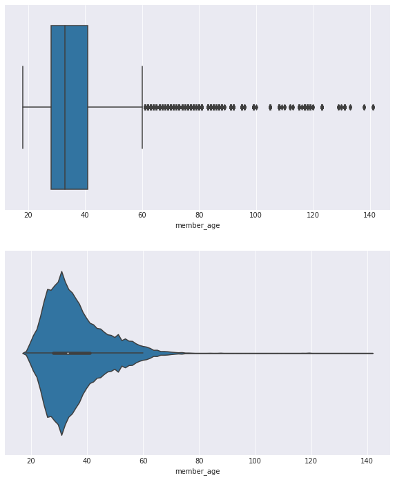

```python
base_color = sns.color_palette()[0]

plt.figure(figsize=(10,12))
plt.subplot(2,1,1)
sns.boxplot(data=df_bike_copy, x='member_age')

plt.subplot(2,1,2)
sns.violinplot(data=df_bike_copy, x='member_age');
```

```python
df_bike_copy = df_bike_copy[df_bike_copy['member_age'] < 60]
```

```python
df_bike_copy.info(verbose=True, null_counts=True)
```

```
<class 'pandas.core.frame.DataFrame'>
Int64Index: 3444695 entries, 0 to 3828131
Data columns (total 26 columns):
Unnamed: 16                22405 non-null object
bike_id                    3444695 non-null object
bike_share_for_all_trip    2985559 non-null category
duration_sec               3444695 non-null int64
end_station_id             3444695 non-null object
end_station_latitude       3444695 non-null float64
end_station_longitude      3444695 non-null float64
end_station_name           3417261 non-null object
end_time                   3444695 non-null datetime64[ns]
member_birth_year          3444695 non-null float64
member_gender              3444695 non-null category
rental_access_method       2781 non-null object
start_station_id           3444695 non-null object
start_station_latitude     3444695 non-null float64
start_station_longitude    3444695 non-null float64
start_station_name         3417393 non-null object
start_time                 3444695 non-null datetime64[ns]
user_type                  3444695 non-null category
start_month                3444695 non-null object
start_weekday              3444695 non-null object
start_hour                 3444695 non-null object
start_day                  3444695 non-null object
end_hour                   3444695 non-null object
end_day                    3444695 non-null object
end_weekday                3444695 non-null object
member_age                 3444695 non-null float64
dtypes: category(3), datetime64[ns](2), float64(6), int64(1), object(14)
memory usage: 640.6+ MB
```

### Define

- Drop the columns 'rental_access_method' and 'Unnamed: 16'

### Code

```python
df_bike_copy.drop(['Unnamed: 16', 'rental_access_method'], axis=1, inplace=True)
```

### Test

```python
df_bike_copy.info(verbose=True, null_counts=True)
```

```
<class 'pandas.core.frame.DataFrame'>
Int64Index: 3444695 entries, 0 to 3828131
Data columns (total 24 columns):
bike_id                    3444695 non-null object
bike_share_for_all_trip    2985559 non-null category
duration_sec               3444695 non-null int64
end_station_id             3444695 non-null object
end_station_latitude       3444695 non-null float64
end_station_longitude      3444695 non-null float64
end_station_name           3417261 non-null object
end_time                   3444695 non-null datetime64[ns]
member_birth_year          3444695 non-null float64
member_gender              3444695 non-null category
start_station_id           3444695 non-null object
start_station_latitude     3444695 non-null float64
start_station_longitude    3444695 non-null float64
start_station_name         3417393 non-null object
start_time                 3444695 non-null datetime64[ns]
user_type                  3444695 non-null category
start_month                3444695 non-null object
start_weekday              3444695 non-null object
start_hour                 3444695 non-null object
start_day                  3444695 non-null object
end_hour                   3444695 non-null object
end_day                    3444695 non-null object
end_weekday                3444695 non-null object
member_age                 3444695 non-null float64
dtypes: category(3), datetime64[ns](2), float64(6), int64(1), object(12)
memory usage: 588.0+ MB
```

### Define

- calculate the distance for each ride entry.

We can either use Haversine or Vincenty Formula to calculate distance between two points using Latitude and Longitude. Haversine is simpler but Vincenty is more accurate. Vincenty is more computational intense. Here, I have used Haversine Formula to calculate distance.

### Code

```python
def cal_dist(lat1,lon1,lat2,lon2):
    r = 6378.1       # Radius of Earth in Km.
    lat1 = radians(lat1)
    lat2 = radians(lat2)
    lon1 = radians(lon1)
    lon2 = radians(lon2)

    dlat = lat2 - lat1
    dlon = lon2 - lon1

    a = sin(dlat/2)**2 + cos(lat1) * cos(lat2) * sin(dlon/2)**2
    c = 2 * atan2(sqrt(a), sqrt(1-a))

    return (r*c)
```

```python
df_bike_copy['distance'] = df_bike_copy.apply(lambda x: cal_dist(x['start_station_latitude'], x['start_station_longitude'],
                                                       x['end_station_latitude'], x['end_station_longitude']), axis = 1)
```

### Test

```python
df_bike_copy['distance'].describe()
```

```
count    3.444695e+06
mean     1.707855e+00
std      3.009775e+01
min      0.000000e+00
25%      8.983255e-01
50%      1.407194e+00
75%      2.136141e+00
max      1.281261e+04
Name: distance, dtype: float64
```

- Minimum distance is zero. Maximun distance is way too large a number considering this dataset. And the maximum trip duration is nearly a day.

```python
df_bike_copy[df_bike_copy['distance'] == 0][['duration_sec', 'start_station_id', 'end_station_id', 'start_station_name', 'end_station_name']]
```

|  | duration_sec | start_station_id | end_station_id | start_station_name | end_station_name |
| --- | --- | --- | --- | --- | --- |
| 97 | 1327 | 50.0 | 50.0 | 2nd St at Townsend St | 2nd St at Townsend St |
| 120 | 423 | 356.0 | 356.0 | Valencia St at Clinton Park | Valencia St at Clinton Park |
| 154 | 4772 | 5.0 | 5.0 | Powell St BART Station (Market St at 5th St) | Powell St BART Station (Market St at 5th St) |
| 219 | 1886 | 35.0 | 35.0 | Cahill Park | Cahill Park |
| 220 | 1867 | 35.0 | 35.0 | Cahill Park | Cahill Park |
| 276 | 2405 | nan | nan | NaN | NaN |
| 279 | 258 | 327.0 | 327.0 | 5th St at San Salvador St | 5th St at San Salvador St |
| 340 | 63 | 67.0 | 67.0 | San Francisco Caltrain Station 2 (Townsend St... | San Francisco Caltrain Station 2 (Townsend St... |
| 343 | 64 | 67.0 | 67.0 | San Francisco Caltrain Station 2 (Townsend St... | San Francisco Caltrain Station 2 (Townsend St... |
| 344 | 1909 | 150.0 | 150.0 | Adeline St at 40th St | Adeline St at 40th St |
| 355 | 63 | 67.0 | 67.0 | San Francisco Caltrain Station 2 (Townsend St... | San Francisco Caltrain Station 2 (Townsend St... |
| 362 | 63 | 67.0 | 67.0 | San Francisco Caltrain Station 2 (Townsend St... | San Francisco Caltrain Station 2 (Townsend St... |
| 378 | 655 | 92.0 | 92.0 | Mission Bay Kids Park | Mission Bay Kids Park |
| 431 | 65 | 24.0 | 24.0 | Spear St at Folsom St | Spear St at Folsom St |
| 446 | 110 | nan | nan | NaN | NaN |
| 457 | 61 | 137.0 | 137.0 | Jersey St at Castro St | Jersey St at Castro St |
| 477 | 2482 | 70.0 | 70.0 | Central Ave at Fell St | Central Ave at Fell St |
| 521 | 744 | 243.0 | 243.0 | Bancroft Way at College Ave | Bancroft Way at College Ave |
| 541 | 1025 | 52.0 | 52.0 | McAllister St at Baker St | McAllister St at Baker St |
| 551 | 131 | 309.0 | 309.0 | San Jose City Hall | San Jose City Hall |
| 554 | 128 | 67.0 | 67.0 | San Francisco Caltrain Station 2 (Townsend St... | San Francisco Caltrain Station 2 (Townsend St... |
| 572 | 175 | 67.0 | 67.0 | San Francisco Caltrain Station 2 (Townsend St... | San Francisco Caltrain Station 2 (Townsend St... |
| 669 | 352 | 368.0 | 368.0 | Myrtle St at Polk St | Myrtle St at Polk St |
| 755 | 67 | 310.0 | 310.0 | San Fernando St at 4th St | San Fernando St at 4th St |
| 877 | 100 | 20.0 | 20.0 | Mechanics Monument Plaza (Market St at Bush St) | Mechanics Monument Plaza (Market St at Bush St) |
| 969 | 6676 | 296.0 | 296.0 | 5th St at Virginia St | 5th St at Virginia St |
| 1108 | 878 | 27.0 | 27.0 | Beale St at Harrison St | Beale St at Harrison St |
| 1217 | 766 | 254.0 | 254.0 | Vine St at Shattuck Ave | Vine St at Shattuck Ave |
| 1272 | 138 | 195.0 | 195.0 | Bay Pl at Vernon St | Bay Pl at Vernon St |
| 1356 | 1191 | 70.0 | 70.0 | Central Ave at Fell St | Central Ave at Fell St |
| ... | ... | ... | ... | ... | ... |
| 3825550 | 988 | 120.0 | 120.0 | Mission Dolores Park | Mission Dolores Park |
| 3825556 | 722 | 201.0 | 201.0 | 10th St at Fallon St | 10th St at Fallon St |
| 3825675 | 1125 | 186.0 | 186.0 | Lakeside Dr at 14th St | Lakeside Dr at 14th St |
| 3825741 | 201 | 93.0 | 93.0 | 4th St at Mission Bay Blvd S | 4th St at Mission Bay Blvd S |
| 3826093 | 1038 | 79.0 | 79.0 | 7th St at Brannan St | 7th St at Brannan St |
| 3826250 | 82 | 16.0 | 16.0 | Steuart St at Market St | Steuart St at Market St |
| 3826288 | 2591 | 283.0 | 283.0 | Delmas Ave and San Fernando St | Delmas Ave and San Fernando St |
| 3826479 | 1104 | 280.0 | 280.0 | San Fernando at 7th St | San Fernando at 7th St |
| 3826512 | 80 | 93.0 | 93.0 | 4th St at Mission Bay Blvd S | 4th St at Mission Bay Blvd S |
| 3826750 | 1712 | 22.0 | 22.0 | Howard St at Beale St | Howard St at Beale St |
| 3826821 | 1829 | 93.0 | 93.0 | 4th St at Mission Bay Blvd S | 4th St at Mission Bay Blvd S |
| 3826912 | 11122 | 182.0 | 182.0 | 19th Street BART Station | 19th Street BART Station |
| 3826971 | 555 | 20.0 | 20.0 | Mechanics Monument Plaza (Market St at Bush St) | Mechanics Monument Plaza (Market St at Bush St) |
| 3826994 | 2017 | 338.0 | 338.0 | 13th St at Franklin St | 13th St at Franklin St |
| 3827002 | 2327 | 93.0 | 93.0 | 4th St at Mission Bay Blvd S | 4th St at Mission Bay Blvd S |
| 3827007 | 1105 | 88.0 | 88.0 | 11th St at Bryant St | 11th St at Bryant St |
| 3827022 | 194 | 148.0 | 148.0 | Horton St at 40th St | Horton St at 40th St |
| 3827069 | 1396 | 159.0 | 159.0 | 24th St at Market St | 24th St at Market St |
| 3827232 | 346 | 17.0 | 17.0 | Embarcadero BART Station (Beale St at Market St) | Embarcadero BART Station (Beale St at Market St) |
| 3827316 | 2233 | 6.0 | 6.0 | The Embarcadero at Sansome St | The Embarcadero at Sansome St |
| 3827333 | 86 | 280.0 | 280.0 | San Fernando at 7th St | San Fernando at 7th St |
| 3827365 | 1725 | 181.0 | 181.0 | Grand Ave at Webster St | Grand Ave at Webster St |
| 3827368 | 2574 | 152.0 | 152.0 | 47th St at San Pablo Ave | 47th St at San Pablo Ave |
| 3827393 | 1571 | 25.0 | 25.0 | Howard St at 2nd St | Howard St at 2nd St |
| 3827435 | 1597 | 74.0 | 74.0 | Laguna St at Hayes St | Laguna St at Hayes St |
| 3827449 | 257 | 305.0 | 305.0 | Ryland Park | Ryland Park |
| 3827471 | 611 | 227.0 | 227.0 | Foothill Blvd at Fruitvale Ave | Foothill Blvd at Fruitvale Ave |
| 3827497 | 783 | 198.0 | 198.0 | Snow Park | Snow Park |
| 3827544 | 505 | 163.0 | 163.0 | Lake Merritt BART Station | Lake Merritt BART Station |
| 3827811 | 921 | 139.0 | 139.0 | Garfield Square (25th St at Harrison St) | Garfield Square (25th St at Harrison St) |

80173 rows × 5 columns

Distance is zero for a few trips beacuse the bike was collected and returned at the same station. We will look into the maximum distance at a later stage.

### Define

Calculate the average speed. This is not the speed at which the user travlled but a good option get a few insights. There would have been pit stops during the ride.

### Code

```python
df_bike_copy['avg_speed'] = df_bike_copy['distance']/df_bike_copy['duration_sec'] * 3600
```

### Test

```python
df_bike_copy['avg_speed'].describe()
```

```
count    3.444695e+06
mean     1.031391e+01
std      2.274168e+02
min      0.000000e+00
25%      7.971890e+00
50%      1.008333e+01
75%      1.220934e+01
max      2.634683e+05
Name: avg_speed, dtype: float64
```

A minimum of zero and a a very large value for maximum. There is a large difference between the values for the 75 percentile and the maximum. The values of zero are due to the zero values in the column 'distance'.

```python
df_bike_copy.info(verbose=True, null_counts=True)
```

```
<class 'pandas.core.frame.DataFrame'>
Int64Index: 3444695 entries, 0 to 3828131
Data columns (total 26 columns):
bike_id                    3444695 non-null object
bike_share_for_all_trip    2985559 non-null category
duration_sec               3444695 non-null int64
end_station_id             3444695 non-null object
end_station_latitude       3444695 non-null float64
end_station_longitude      3444695 non-null float64
end_station_name           3417261 non-null object
end_time                   3444695 non-null datetime64[ns]
member_birth_year          3444695 non-null float64
member_gender              3444695 non-null category
start_station_id           3444695 non-null object
start_station_latitude     3444695 non-null float64
start_station_longitude    3444695 non-null float64
start_station_name         3417393 non-null object
start_time                 3444695 non-null datetime64[ns]
user_type                  3444695 non-null category
start_month                3444695 non-null object
start_weekday              3444695 non-null object
start_hour                 3444695 non-null object
start_day                  3444695 non-null object
end_hour                   3444695 non-null object
end_day                    3444695 non-null object
end_weekday                3444695 non-null object
member_age                 3444695 non-null float64
distance                   3444695 non-null float64
avg_speed                  3444695 non-null float64
dtypes: category(3), datetime64[ns](2), float64(8), int64(1), object(12)
memory usage: 640.6+ MB
```

### Define

Check for outliers in distance and average speed.

### Code

```python
df_bike_copy.loc[df_bike_copy['distance'].idxmax()]
```

```
bike_id                                           150
bike_share_for_all_trip                            No
duration_sec                                     1491
end_station_id                                  420.0
end_station_latitude                                0
end_station_longitude                               0
end_station_name                      SF Test Station
end_time                   2019-04-28 19:05:33.063000
member_birth_year                                1981
member_gender                                    Male
start_station_id                                377.0
start_station_latitude                        37.7719
start_station_longitude                      -122.454
start_station_name              Fell St at Stanyan St
start_time                 2019-04-28 18:40:41.288000
user_type                                    Customer
start_month                                     April
start_weekday                                     Sun
start_hour                                         18
start_day                                          28
end_hour                                           19
end_day                                            28
end_weekday                                       Sun
member_age                                         38
distance                                      12812.6
avg_speed                                     30935.9
Name: 3053214, dtype: object
```

Distance of 12812 Kms travelled in 25 mins with an average speed of 31000 Km/hr. The fields of latitude and longitude for the snd station are zero. This is the reason for error in the calculation of distance and speed.

```python
df_bike_copy.loc[df_bike_copy['avg_speed'].idxmax()]
```

```
bike_id                                          1161
bike_share_for_all_trip                            No
duration_sec                                      175
end_station_id                                   81.0
end_station_latitude                          37.7759
end_station_longitude                        -122.393
end_station_name                   Berry St at 4th St
end_time                   2019-04-24 16:59:50.429000
member_birth_year                                1983
member_gender                                    Male
start_station_id                                420.0
start_station_latitude                              0
start_station_longitude                             0
start_station_name                    SF Test Station
start_time                 2019-04-24 16:56:54.516000
user_type                                  Subscriber
start_month                                     April
start_weekday                                     Wed
start_hour                                         16
start_day                                          24
end_hour                                           16
end_day                                            24
end_weekday                                       Wed
member_age                                         36
distance                                      12807.5
avg_speed                                      263468
Name: 3078608, dtype: object
```

Distance of 12807 Kms travelled in 3 mins at an again insane speed. Here, The fields of latitude and longitude are zero for the start station.

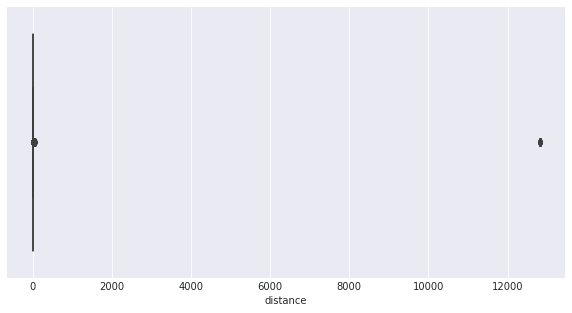

```python
plt.figure(figsize=(10,5))
sns.boxplot(data=df_bike_copy, x='distance');
```

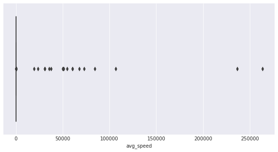

```python
plt.figure(figsize=(10,5))
sns.boxplot(data=df_bike_copy, x='avg_speed');
```

Above graphs prove the presence of not one but many such outliers.

```python
df_bike_copy[df_bike_copy['avg_speed'] > 9000]
```

|  | bike_id | bike_share_for_all_trip | duration_sec | end_station_id | end_station_latitude | end_station_longitude | end_station_name | end_time | member_birth_year | member_gender | ... | start_month | start_weekday | start_hour | start_day | end_hour | end_day | end_weekday | member_age | distance | avg_speed |
| --- | --- | --- | --- | --- | --- | --- | --- | --- | --- | --- | --- | --- | --- | --- | --- | --- | --- | --- | --- | --- | --- |
| 3039105 | 1612 | No | 2365 | 420.0 | 0.00000 | 0.00000 | SF Test Station | 2019-04-30 19:01:08.146 | 1995.0 | Female | ... | April | Tue | 18 | 30 | 19 | 30 | Tue | 24.0 | 12807.062043 | 19494.893596 |
| 3039871 | 3507 | No | 1964 | 420.0 | 0.00000 | 0.00000 | SF Test Station | 2019-04-30 18:04:04.518 | 1981.0 | Female | ... | April | Tue | 17 | 30 | 18 | 30 | Tue | 38.0 | 12810.276009 | 23481.157654 |
| 3040025 | 1142 | Yes | 546 | 420.0 | 0.00000 | 0.00000 | SF Test Station | 2019-04-30 17:54:45.258 | 1991.0 | Female | ... | April | Tue | 17 | 30 | 17 | 30 | Tue | 28.0 | 12808.672812 | 84452.787772 |
| 3040104 | 3500 | No | 630 | 420.0 | 0.00000 | 0.00000 | SF Test Station | 2019-04-30 17:50:04.314 | 1991.0 | Male | ... | April | Tue | 17 | 30 | 17 | 30 | Tue | 28.0 | 12807.557878 | 73186.045019 |
| 3040557 | 1181 | No | 433 | 420.0 | 0.00000 | 0.00000 | SF Test Station | 2019-04-30 17:24:23.919 | 1995.0 | Male | ... | April | Tue | 17 | 30 | 17 | 30 | Tue | 24.0 | 12807.054315 | 106478.973518 |
| 3040640 | 2535 | No | 1233 | 420.0 | 0.00000 | 0.00000 | SF Test Station | 2019-04-30 17:19:14.689 | 1970.0 | Male | ... | April | Tue | 16 | 30 | 17 | 30 | Tue | 49.0 | 12807.485745 | 37394.118964 |
| 3040672 | 462 | No | 1306 | 420.0 | 0.00000 | 0.00000 | SF Test Station | 2019-04-30 17:17:22.162 | 1992.0 | Male | ... | April | Tue | 16 | 30 | 17 | 30 | Tue | 27.0 | 12807.861712 | 35304.978686 |
| 3040963 | 1880 | No | 764 | 420.0 | 0.00000 | 0.00000 | SF Test Station | 2019-04-30 16:56:56.539 | 1976.0 | Male | ... | April | Tue | 16 | 30 | 16 | 30 | Tue | 43.0 | 12806.852977 | 60346.427641 |
| 3053214 | 150 | No | 1491 | 420.0 | 0.00000 | 0.00000 | SF Test Station | 2019-04-28 19:05:33.063 | 1981.0 | Male | ... | April | Sun | 18 | 28 | 19 | 28 | Sun | 38.0 | 12812.609654 | 30935.878440 |
| 3053267 | 311 | No | 680 | 420.0 | 0.00000 | 0.00000 | SF Test Station | 2019-04-28 18:51:28.357 | 1981.0 | Female | ... | April | Sun | 18 | 28 | 18 | 28 | Sun | 38.0 | 12810.024820 | 67817.778459 |
| 3053382 | 333 | No | 764 | 420.0 | 0.00000 | 0.00000 | SF Test Station | 2019-04-28 18:23:22.476 | 1989.0 | Male | ... | April | Sun | 18 | 28 | 18 | 28 | Sun | 30.0 | 12812.583812 | 60373.431576 |
| 3053383 | 2760 | No | 904 | 420.0 | 0.00000 | 0.00000 | SF Test Station | 2019-04-28 18:23:18.367 | 1989.0 | Male | ... | April | Sun | 18 | 28 | 18 | 28 | Sun | 30.0 | 12812.583812 | 51023.563854 |
| 3053414 | 3632 | No | 1501 | 420.0 | 0.00000 | 0.00000 | SF Test Station | 2019-04-28 18:17:28.410 | 1997.0 | Male | ... | April | Sun | 17 | 28 | 18 | 28 | Sun | 22.0 | 12812.609654 | 30729.776652 |
| 3053415 | 901 | No | 1503 | 420.0 | 0.00000 | 0.00000 | SF Test Station | 2019-04-28 18:17:25.545 | 1995.0 | Male | ... | April | Sun | 17 | 28 | 18 | 28 | Sun | 24.0 | 12812.609654 | 30688.885399 |
| 3053434 | 536 | No | 840 | 420.0 | 0.00000 | 0.00000 | SF Test Station | 2019-04-28 18:14:23.599 | 1981.0 | Male | ... | April | Sun | 18 | 28 | 18 | 28 | Sun | 38.0 | 12809.243512 | 54896.757910 |
| 3078608 | 1161 | No | 175 | 81.0 | 37.77588 | -122.39317 | Berry St at 4th St | 2019-04-24 16:59:50.429 | 1983.0 | Male | ... | April | Wed | 16 | 24 | 16 | 24 | Wed | 36.0 | 12807.485745 | 263468.278187 |
| 3078650 | 3498 | No | 195 | 420.0 | 0.00000 | 0.00000 | SF Test Station | 2019-04-24 16:56:51.006 | 1970.0 | Female | ... | April | Wed | 16 | 24 | 16 | 24 | Wed | 49.0 | 12807.650357 | 236448.929673 |
| 3087547 | 1768 | No | 921 | 420.0 | 0.00000 | 0.00000 | SF Test Station | 2019-04-23 13:29:31.333 | 1967.0 | Male | ... | April | Tue | 13 | 23 | 13 | 23 | Tue | 52.0 | 12807.346014 | 50061.287350 |
| 3125748 | 1939 | No | 912 | 420.0 | 0.00000 | 0.00000 | SF Test Station | 2019-04-17 09:45:24.263 | 1982.0 | Male | ... | April | Wed | 09 | 17 | 09 | 17 | Wed | 37.0 | 12809.940825 | 50565.555889 |

19 rows × 26 columns

```python
df_bike_copy[df_bike_copy['avg_speed'] < 10000].describe()
```

|  | duration_sec | end_station_latitude | end_station_longitude | member_birth_year | start_station_latitude | start_station_longitude | member_age | distance | avg_speed |
| --- | --- | --- | --- | --- | --- | --- | --- | --- | --- |
| count | 3.444676e+06 | 3.444676e+06 | 3.444676e+06 | 3.444676e+06 | 3.444676e+06 | 3.444676e+06 | 3.444676e+06 | 3.444676e+06 | 3.444676e+06 |
| mean | 7.711983e+02 | 3.776751e+01 | -1.223499e+02 | 1.984294e+03 | 3.776740e+01 | -1.223505e+02 | 3.470642e+01 | 1.637211e+00 | 9.917080e+00 |
| std | 1.952487e+03 | 1.041197e-01 | 1.458745e-01 | 8.985278e+00 | 1.042354e-01 | 1.463249e-01 | 8.985278e+00 | 1.045848e+00 | 3.678525e+00 |
| min | 6.000000e+01 | 3.724823e+01 | -1.224737e+02 | 1.960000e+03 | 3.726331e+01 | -1.224737e+02 | 1.800000e+01 | 0.000000e+00 | 0.000000e+00 |
| 25% | 3.460000e+02 | 3.777106e+01 | -1.224107e+02 | 1.979000e+03 | 3.777106e+01 | -1.224117e+02 | 2.800000e+01 | 8.983255e-01 | 7.971877e+00 |
| 50% | 5.440000e+02 | 3.778107e+01 | -1.223971e+02 | 1.986000e+03 | 3.778107e+01 | -1.223974e+02 | 3.300000e+01 | 1.407194e+00 | 1.008333e+01 |
| 75% | 8.390000e+02 | 3.779625e+01 | -1.222894e+02 | 1.991000e+03 | 3.779581e+01 | -1.222887e+02 | 4.000000e+01 | 2.136141e+00 | 1.220931e+01 |
| max | 8.628100e+04 | 4.551000e+01 | -7.357000e+01 | 2.001000e+03 | 4.551000e+01 | -7.357000e+01 | 5.900000e+01 | 6.954666e+01 | 4.921400e+01 |

The descriptive statistics look better without these entries. Lets drop these outliers.

```python
df_bike_copy = df_bike_copy[df_bike_copy['avg_speed'] < 10000]
```

### Test

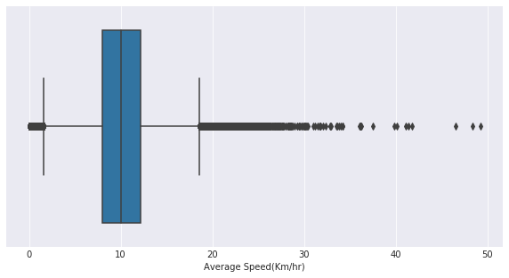

```python
plt.figure(figsize=(10,5))
sns.boxplot(data=df_bike_copy, x='avg_speed')
plt.xlabel('Average Speed(Km/hr)');
```

```python
df_bike_copy[df_bike_copy['avg_speed'] > 40][['duration_sec', 'distance', 'avg_speed', 'member_age']]
```

|  | duration_sec | distance | avg_speed | member_age |
| --- | --- | --- | --- | --- |
| 63553 | 96 | 1.113188 | 41.744567 | 24.0 |
| 96305 | 248 | 3.328671 | 48.319420 | 31.0 |
| 386648 | 5471 | 62.363103 | 41.035857 | 43.0 |
| 2320837 | 104 | 1.421738 | 49.213997 | 20.0 |
| 2323062 | 77 | 0.884333 | 41.345447 | 25.0 |
| 2741002 | 100 | 1.113188 | 40.074784 | 34.0 |
| 2765399 | 110 | 1.421664 | 46.527195 | 25.0 |

A reasonably fit rider can ride at speed of around 40km/hr on a racing bicycle. Given, The distance is fairly low for these cases, It's possible except for one.

Distance of 62 kms in 1.5 hrs!!. I will drop this particular entry as well.

```python
df_bike_copy.drop(386648, inplace=True)
df_bike_copy[df_bike_copy['avg_speed'] > 40][['duration_sec', 'distance', 'avg_speed', 'member_age']]
```

|  | duration_sec | distance | avg_speed | member_age |
| --- | --- | --- | --- | --- |
| 63553 | 96 | 1.113188 | 41.744567 | 24.0 |
| 96305 | 248 | 3.328671 | 48.319420 | 31.0 |
| 2320837 | 104 | 1.421738 | 49.213997 | 20.0 |
| 2323062 | 77 | 0.884333 | 41.345447 | 25.0 |
| 2741002 | 100 | 1.113188 | 40.074784 | 34.0 |
| 2765399 | 110 | 1.421664 | 46.527195 | 25.0 |

```python
df_bike_copy['distance'].max()
```

```
69.54665892229626
```

As expected, Dropping outliers in average speed has also cleaned the outliers in distance.

```python
df_bike_copy.info(verbose=True, null_counts=True)
```

```
<class 'pandas.core.frame.DataFrame'>
Int64Index: 3444675 entries, 0 to 3828131
Data columns (total 26 columns):
bike_id                    3444675 non-null object
bike_share_for_all_trip    2985540 non-null category
duration_sec               3444675 non-null int64
end_station_id             3444675 non-null object
end_station_latitude       3444675 non-null float64
end_station_longitude      3444675 non-null float64
end_station_name           3417241 non-null object
end_time                   3444675 non-null datetime64[ns]
member_birth_year          3444675 non-null float64
member_gender              3444675 non-null category
start_station_id           3444675 non-null object
start_station_latitude     3444675 non-null float64
start_station_longitude    3444675 non-null float64
start_station_name         3417373 non-null object
start_time                 3444675 non-null datetime64[ns]
user_type                  3444675 non-null category
start_month                3444675 non-null object
start_weekday              3444675 non-null object
start_hour                 3444675 non-null object
start_day                  3444675 non-null object
end_hour                   3444675 non-null object
end_day                    3444675 non-null object
end_weekday                3444675 non-null object
member_age                 3444675 non-null float64
distance                   3444675 non-null float64
avg_speed                  3444675 non-null float64
dtypes: category(3), datetime64[ns](2), float64(8), int64(1), object(12)
memory usage: 640.6+ MB
```

## Store

```python
df_bike_copy.to_csv('bike_master_df.csv', index=False)
```

## Analyze

```python
df_bike_master = pd.read_csv('bike_master_df.csv')
```

```python
df_bike_master.info(verbose=True, null_counts=True)
```

```
<class 'pandas.core.frame.DataFrame'>
RangeIndex: 3444675 entries, 0 to 3444674
Data columns (total 26 columns):
bike_id                    3444675 non-null int64
bike_share_for_all_trip    2985540 non-null object
duration_sec               3444675 non-null int64
end_station_id             3417239 non-null float64
end_station_latitude       3444675 non-null float64
end_station_longitude      3444675 non-null float64
end_station_name           3417241 non-null object
end_time                   3444675 non-null object
member_birth_year          3444675 non-null float64
member_gender              3444675 non-null object
start_station_id           3417370 non-null float64
start_station_latitude     3444675 non-null float64
start_station_longitude    3444675 non-null float64
start_station_name         3417373 non-null object
start_time                 3444675 non-null object
user_type                  3444675 non-null object
start_month                3444675 non-null object
start_weekday              3444675 non-null object
start_hour                 3444675 non-null int64
start_day                  3444675 non-null int64
end_hour                   3444675 non-null int64
end_day                    3444675 non-null int64
end_weekday                3444675 non-null object
member_age                 3444675 non-null float64
distance                   3444675 non-null float64
avg_speed                  3444675 non-null float64
dtypes: float64(10), int64(6), object(10)
memory usage: 683.3+ MB
```

- The datatypes of a few columns are incorrect. We will make the required changes as well as change the dataypes of columns 'start_month', 'start_weekday' and 'end_weekday' to ordered category Datatype.

```python
df_bike_master['bike_id'] = df_bike_master['bike_id'].astype(str)
df_bike_master['start_station_id'] = df_bike_master['start_station_id'].astype(str)
df_bike_master['end_station_id']= df_bike_master['end_station_id'].astype(str)

df_bike_master['user_type'] = df_bike_master['user_type'].astype('category')
df_bike_master['bike_share_for_all_trip'] = df_bike_master['bike_share_for_all_trip'].astype('category')
df_bike_master['member_gender'] = df_bike_master['member_gender'].astype('category')

df_bike_master['start_time'] = pd.to_datetime(df_bike_master['start_time'])
df_bike_master['end_time'] = pd.to_datetime(df_bike_master['end_time'])
```

```python
level_order = {'start_month':['January', 'February', 'March', 'April', 'May', 'June', 'July', 'August', 'September',
                              'October', 'November', 'December'],
               'start_weekday': ['Mon', 'Tue', 'Wed', 'Thu', 'Fri', 'Sat', 'Sun'],
               'end_weekday': ['Mon', 'Tue', 'Wed', 'Thu', 'Fri', 'Sat', 'Sun']}

for col in level_order:
    ordered_cat = pd.api.types.CategoricalDtype(ordered=True, categories=level_order[col])
    df_bike_master[col] = df_bike_master[col].astype(ordered_cat)
```

```python
df_bike_master.info(verbose=True, null_counts=True)
```

```
<class 'pandas.core.frame.DataFrame'>
RangeIndex: 3444675 entries, 0 to 3444674
Data columns (total 26 columns):
bike_id                    3444675 non-null object
bike_share_for_all_trip    2985540 non-null category
duration_sec               3444675 non-null int64
end_station_id             3444675 non-null object
end_station_latitude       3444675 non-null float64
end_station_longitude      3444675 non-null float64
end_station_name           3417241 non-null object
end_time                   3444675 non-null datetime64[ns]
member_birth_year          3444675 non-null float64
member_gender              3444675 non-null category
start_station_id           3444675 non-null object
start_station_latitude     3444675 non-null float64
start_station_longitude    3444675 non-null float64
start_station_name         3417373 non-null object
start_time                 3444675 non-null datetime64[ns]
user_type                  3444675 non-null category
start_month                3444675 non-null category
start_weekday              3444675 non-null category
start_hour                 3444675 non-null int64
start_day                  3444675 non-null int64
end_hour                   3444675 non-null int64
end_day                    3444675 non-null int64
end_weekday                3444675 non-null category
member_age                 3444675 non-null float64
distance                   3444675 non-null float64
avg_speed                  3444675 non-null float64
dtypes: category(6), datetime64[ns](2), float64(8), int64(5), object(5)
memory usage: 545.3+ MB
```

### What is the structure of your dataset?

The dataset has been a mix of information previously provided and the additional information extracted.

### What is/are the main feature(s) of interest in your dataset?

> The main features of interest are the months, weekdays and time of the day of high demand. How other factors like the age and gender of user affect them. Number of random users compared to the subscribers.

### What features in the dataset do you think will help support your investigation into your feature(s) of interest?

> The distance and duration of trip will help get an insight. Member age shall also play an important role.

## Univariate Exploration

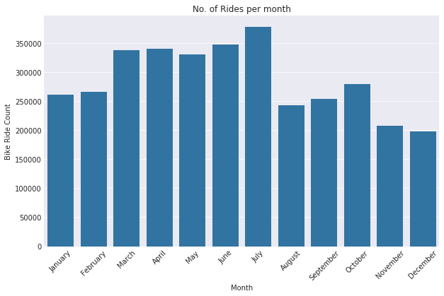

```python
base_color = sns.color_palette()[0]
plt.figure(figsize=(10,6))
g = sns.countplot(data=df_bike_master, x='start_month', color=base_color)
plt.xticks(rotation = 45)
plt.xlabel('Month')
plt.ylabel('Bike Ride Count')
plt.title('No. of Rides per month');
```

- Frequency of rides is highest during the month of July. Followed by months of June, April, March and May. Summers have the highest demand of Ford GoBike. Winters have the least number of rides. December and November having the least couny of rides.

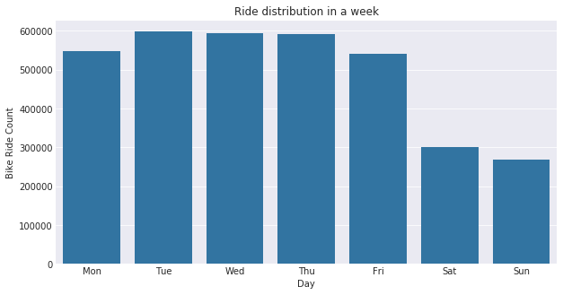

```python
plt.figure(figsize=(10,5))
g = sns.countplot(data=df_bike_master, x='start_weekday', color=base_color)
plt.xlabel('Day')
plt.ylabel('Bike Ride Count')
plt.title('Ride distribution in a week');
```

- Apparantly, Weekends have the least number of rides. Tuesday, Wednessday and Thursday having highest count. We have a moderate count for Monday and Friday. I expected highest frequency on weekends.

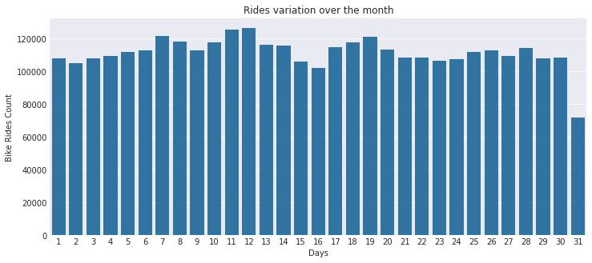

```python
plt.figure(figsize=(12,5))
g = sns.countplot(data=df_bike_master, x='start_day', color=base_color)
plt.title('Rides variation over the month')
plt.xlabel('Days')
plt.ylabel('Bike Rides Count');
```

- Not a lot can be said from the above plot. The data is spread throughout. I was not expecting a lot from this particular plot.

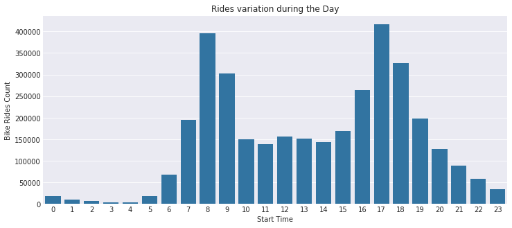

```python
plt.figure(figsize=(12,5))
g = sns.countplot(data=df_bike_master, x='start_hour', color=base_color)
plt.title('Rides variation during the Day')
plt.xlabel('Start Time')
plt.ylabel('Bike Rides Count');
```

We have the peak hours during 8 to 9 in morning and 16 to 18 in the evening. And a moderate use during the day.

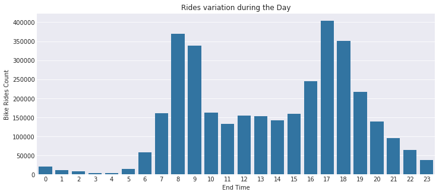

```python
plt.figure(figsize=(12,5))
g = sns.countplot(data=df_bike_master, x='end_hour', color=base_color)
plt.title('Rides variation during the Day')
plt.xlabel('End Time')
plt.ylabel('Bike Rides Count');
```

- We have the peak hours during 8 to 9 in morning and 16 to 18 in the evening. And a moderate use during the day. Start and end time grahs are similar. From the above graphs, It can be said that mostly the bikes are used during the office commute hours. Bike are probably used mostly for office and college commute.

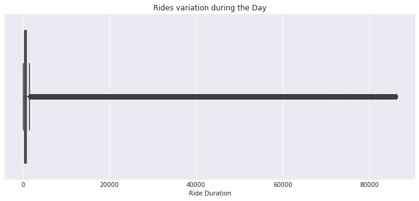

```python
plt.figure(figsize=(12,5))
sns.boxplot(data=df_bike_master, x='duration_sec')
plt.title('Rides variation during the Day')
plt.xlabel('Ride Duration');
```

```python
df_bike_master[df_bike_master['duration_sec']>3500]['bike_id'].shape
```

```
(37196,)
```

- Majority of the rides are for short duration but quite a few range upto 23 hours. Only about 1% of the total entries are more than an hour.

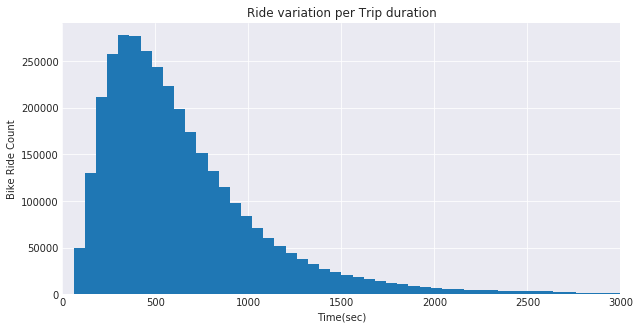

```python
plt.figure(figsize=(10,5))
bins = np.arange(df_bike_master['duration_sec'].min(),df_bike_master['duration_sec'].max()+60, 60)
plt.hist(df_bike_master['duration_sec'], bins=bins)
plt.xlim(0,3000)
plt.xlabel('Time(sec)')
plt.ylabel('Bike Ride Count')
plt.title('Ride variation per Trip duration');
```

- The highest frequency of rides is for the duration of about 5 to 6 minutes. Number of rides decreases as the trip duration increases.

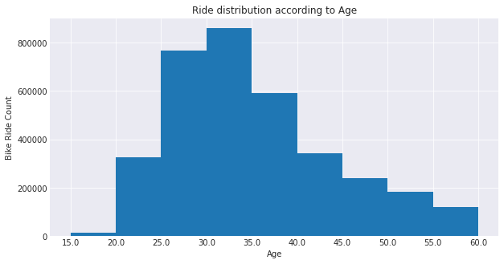

```python
bins = np.arange(15, df_bike_master['member_age'].max()+5, 5)

plt.figure(figsize=(10,5))
plt.hist(data=df_bike_master, x='member_age', bins=bins)
plt.xticks(bins, bins)
plt.xlabel('Age')
plt.ylabel('Bike Ride Count')
plt.title('Ride distribution according to Age');
```

- Maximum rides are for the users within the age 30 to 35. Most users are within the age range of 25 to 40. Number of rides decreases as the age increases.

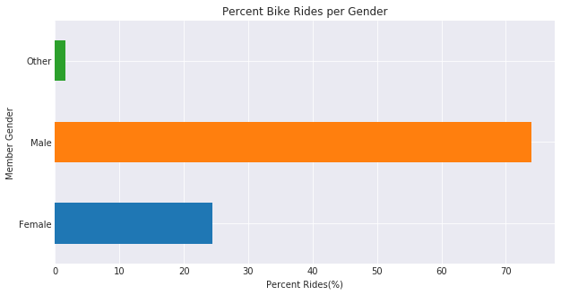

```python
plt.figure(figsize=(10,5))
df = df_bike_master.groupby('member_gender')['bike_id'].size()
df = df/df_bike_master.shape[0]*100
df.plot(kind='barh')
plt.xlabel('Percent Rides(%)')
plt.ylabel('Member Gender')
plt.title('Percent Bike Rides per Gender');
```

- Majority users are Males with around 73% users and about 24% Female users.

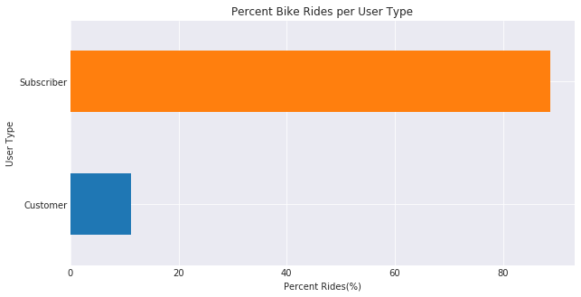

```python
plt.figure(figsize=(10,5))
df = df_bike_master.groupby('user_type')['bike_id'].size()
df = df/df_bike_master.shape[0]*100
df.plot(kind='barh')
plt.xlabel('Percent Rides(%)')
plt.ylabel('User Type')
plt.title('Percent Bike Rides per User Type');
```

- Most of the users are subscribers. Around 88% of the rides are used by the Subscribers and rest 12% are by random customers.

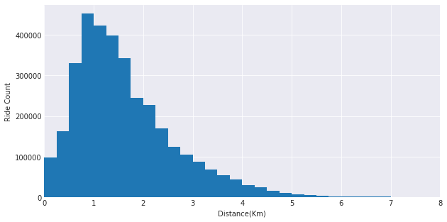

```python
plt.figure(figsize=(10,5))
bins = np.arange(0,8,0.25)
plt.hist(data=df_bike_master, x='distance', bins=bins)
plt.xlabel('Distance(Km)')
plt.ylabel('Ride Count')
plt.xlim(0,8);
```

- Most trips are for short distance. Maximum rides range from 0.5 km to 1.75 km.

### Discuss the distribution(s) of your variable(s) of interest. Were there any unusual points? Did you need to perform any transformations?

> There are some specific patterns in the usage of Ford Gobike. There is quite a contrast when it comes to Summer v/s winter and Weekdays v/s Weekends. Demand timimgs seem to be affected by the office hours. There are outliers in the duration of the trip. Most of the users are fairly young.

### Of the features you investigated, were there any unusual distributions? Did you perform any operations on the data to tidy, adjust, or change the form of the data? If so, why did you do this?

> There were entries with users aged upto 140 years. Users with age above 60 consisted for only about 2.7% of the data. Majority of the rides are for shorter distances and duration. Entries with user age above 60 are dropped. Bikes are kept for long duration but the distance travlled is less. There are entries with incorrect latitude and longitude values for start or end stations. These entries are dropped. Most of the trips are less than an hour long.

## Bivariate Exploration

```python
numeric_var = ['duration_sec', 'distance', 'avg_speed', 'start_hour', 'start_day', 'end_hour', 'end_day']
```

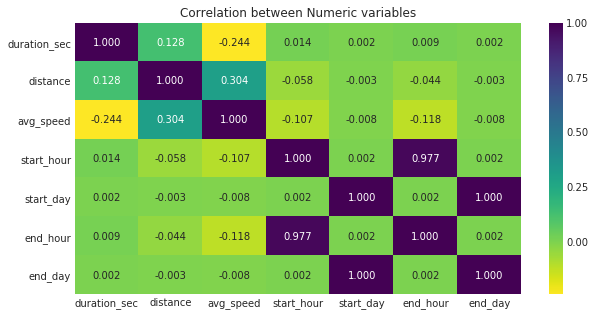

```python
fig,ax = plt.subplots(figsize=(10,5))
sns.heatmap(df_bike_master[numeric_var].corr(), annot=True, fmt='.3f', cmap='viridis_r', ax=ax)
ax.set_title('Correlation between Numeric variables');
```

- Trip durations are mostly less than an hour. Therefore a high correlation between start and end day as well as start and end hour. Duration and distance have a low correlation.

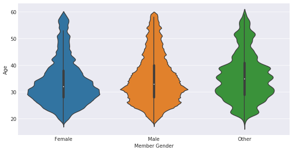

```python
plt.figure(figsize=(10,5))
sns.violinplot(data=df_bike_master, x='member_gender', y='member_age')
plt.xlabel('Member Gender')
plt.ylabel('Age');
```

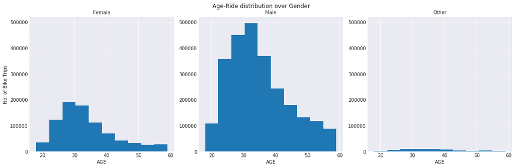

```python
g = sns.FacetGrid(data=df_bike_master, col='member_gender', size=5)
g.map(plt.hist, 'member_age')
plt.subplots_adjust(top=0.9)
g.fig.suptitle('Age-Ride distribution over Gender')
g.set_axis_labels("AGE", "No. of Bike Trips")
g.set_titles('{col_name}');
```

- Member age trend did not change a lot with gender. Overall peak was for 30 to 35 which is the same as male users. Whereas in females ride count peak is for ages between 25 to 30.

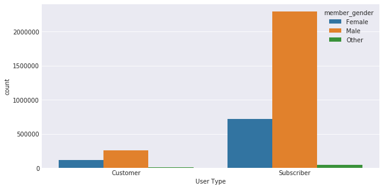

```python
plt.figure(figsize=(10,5))
sns.countplot(data=df_bike_master, x='user_type', hue='member_gender')
plt.xlabel('User Type');
```

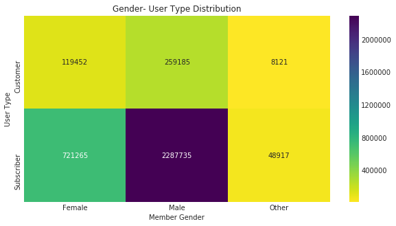

```python
df = df_bike_master.groupby(['user_type', 'member_gender']).size()
df = df.reset_index(name='count')
df = df.pivot(index='user_type', columns='member_gender', values='count')
fig,ax = plt.subplots(figsize = (10,5))
sns.heatmap(df, ax=ax, cmap='viridis_r', annot=True, fmt='d')
ax.set_title('Gender- User Type Distribution')
ax.set(xlabel='Member Gender', ylabel='User Type');
```

- Subsciber and Customer trends are similar with a more number of male users than female users.

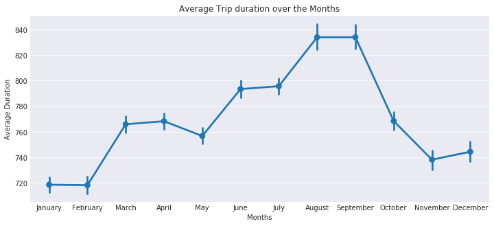

```python
fig,ax = plt.subplots(figsize = (12,5))
sns.pointplot(ax=ax, data=df_bike_master, x='start_month', y='duration_sec')
ax.set_title('Average Trip duration over the Months')
ax.set(xlabel='Months', ylabel='Average Duration');
```

- Average trip duration is highest for months of August and September and least for months of January and February. Average duration increases by around 2 minutes or by 15%.

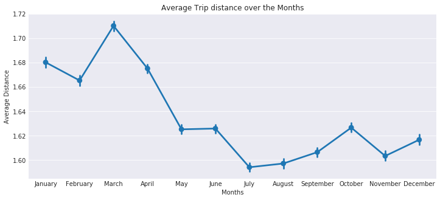

```python
fig,ax = plt.subplots(figsize = (12,5))
sns.pointplot(ax=ax, data=df_bike_master, x='start_month', y='distance')
ax.set_title('Average Trip distance over the Months')
ax.set(xlabel='Months', ylabel='Average Distance');
```

- Average trip distance is maximum for March and least for July.

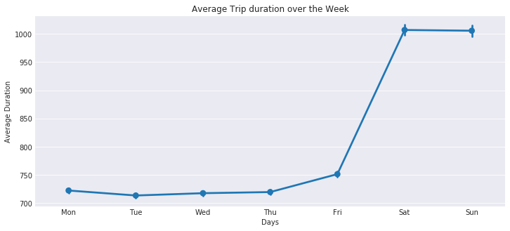

```python
fig,ax = plt.subplots(figsize = (12,5))
sns.pointplot(ax=ax, data=df_bike_master, x='start_weekday', y='duration_sec')
ax.set_title('Average Trip duration over the Week')
ax.set(xlabel='Days', ylabel='Average Duration');
```

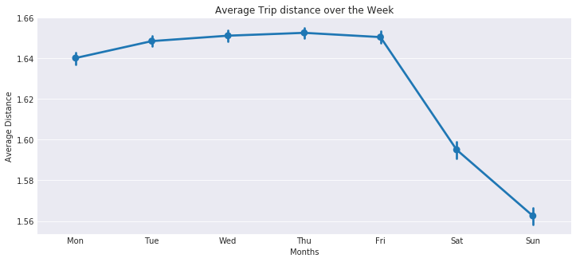

```python
fig,ax = plt.subplots(figsize = (12,5))
sns.pointplot(ax=ax, data=df_bike_master, x='start_weekday', y='distance')
ax.set_title('Average Trip distance over the Week')
ax.set(xlabel='Months', ylabel='Average Distance');
```

- Average trip duration increases by more than 30% on the weekend but the average distance decreases by 5%.

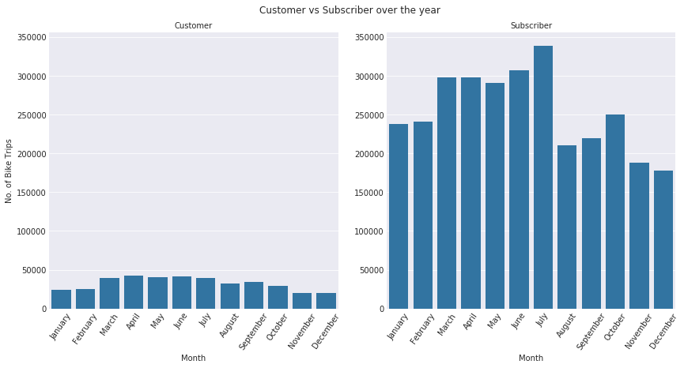

```python
g = sns.FacetGrid(data=df_bike_master, col='user_type', size=6)
g.map(sns.countplot, 'start_month')
g.set_xticklabels(rotation=55)
plt.subplots_adjust(top=0.9)
g.fig.suptitle('Customer vs Subscriber over the year')
g.set_axis_labels("Month", "No. of Bike Trips")
g.set_titles('{col_name}');
```

- Subscribers have the similar trend as the overall trend. It is probably because the dataset is subscriber heavy. Subscribers and customers both have the more number of rides in summer than winter. Subscribers have peak around July whereas customers have peak in April.

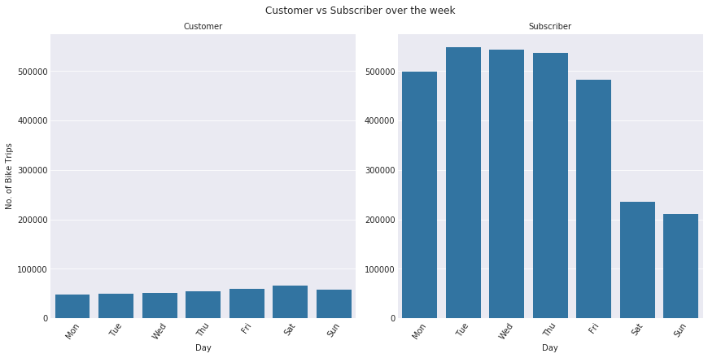

```python
g = sns.FacetGrid(data=df_bike_master, col='user_type', size=6)
g.map(sns.countplot, 'start_weekday')
g.set_xticklabels(rotation=55)
plt.subplots_adjust(top=0.9)
g.fig.suptitle('Customer vs Subscriber over the week')
g.set_axis_labels("Day", "No. of Bike Trips")
g.set_titles('{col_name}');
```

- Subscribers use Ford GoBike more during the weekdays whereas Customers have more ride counts during Saturday.

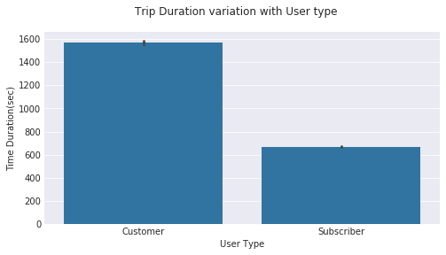

```python
base_color = sns.color_palette()[0]
fig,ax = plt.subplots(figsize=(8,4))
sns.barplot(data=df_bike_master,ax=ax, x='user_type', y='duration_sec', color=base_color)
plt.suptitle('Trip Duration variation with User type')
plt.xlabel('User Type')
plt.ylabel('Time Duration(sec)');
```

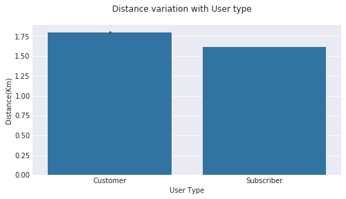

```python
base_color = sns.color_palette()[0]
fig,ax = plt.subplots(figsize=(8,4))
sns.barplot(data=df_bike_master,ax=ax, x='user_type', y='distance', color=base_color)
plt.suptitle('Distance variation with User type')
plt.xlabel('User Type')
plt.ylabel('Distance(Km)');
```

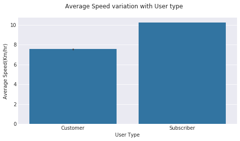

```python
base_color = sns.color_palette()[0]
fig,ax = plt.subplots(figsize=(8,4))
sns.barplot(data=df_bike_master,ax=ax, x='user_type', y='avg_speed', color=base_color)
plt.suptitle('Average Speed variation with User type')
plt.xlabel('User Type')
plt.ylabel('Average Speed(Km/hr)');
```

- Customers use bikes for a longer distance and duration than subscribers.

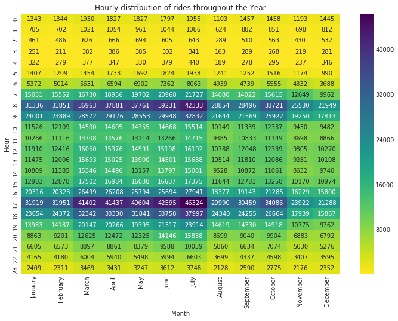

```python
df = df_bike_master.groupby(['start_month', 'start_hour']).size()
df = df.reset_index(name='count')
df = df.pivot(index='start_hour', columns='start_month', values='count')
fig,ax = plt.subplots(figsize=(12,8))
sns.heatmap(df,annot=True, fmt='d', cmap='viridis_r', ax=ax)
ax.set_title('Hourly distribution of rides throughout the Year')
ax.set(xlabel='Month', ylabel='Hour');
```

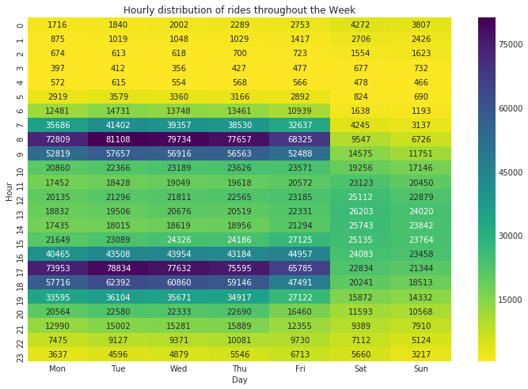

```python
df = df_bike_master.groupby(['start_weekday', 'start_hour']).size()
df = df.reset_index(name='count')
df = df.pivot(index='start_hour', columns='start_weekday', values='count')
fig,ax = plt.subplots(figsize=(12,8))
sns.heatmap(df,annot=True, fmt='d', cmap='viridis_r', ax=ax)
ax.set_title('Hourly distribution of rides throughout the Week')
ax.set(xlabel='Day', ylabel='Hour');
```

- 8 and 17 are the busiest hours of the day throughout the year.
- Weekends have the minimum amount of traffic.
- Overall peak hours of the day are 7 to 9 and 16 to 19.
- Months from March to July receive the most traffic.
- There is some amount of traffic even through the night.

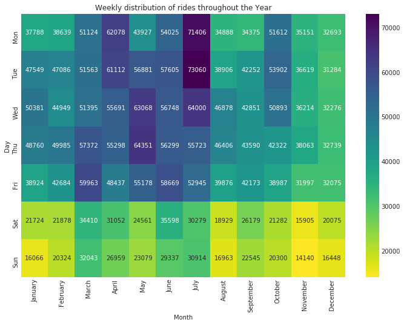

```python
df = df_bike_master.groupby(['start_month', 'start_weekday']).size()
df = df.reset_index(name='count')
df = df.pivot(index='start_weekday', columns='start_month', values='count')
fig,ax = plt.subplots(figsize=(12,8))
sns.heatmap(df,annot=True, fmt='d', cmap='viridis_r', ax=ax)
ax.set_title('Weekly distribution of rides throughout the Year')
ax.set(xlabel='Month', ylabel='Day');
```

- Monday and Tuesday in July will have the highest demand.
- Tuesday to Thursday from April to July have the overall highest demand.
- Weekends have the least demand as well as the months of November and December.
- Rest of the time we have moderate demand.

### Talk about some of the relationships you observed in this part of the investigation. How did the feature(s) of interest vary with other features in the dataset?

> - Long duration trips are in the months of August and September whereas long distance trips are in the month of March.
> - Weekends are the days for trips with long duration whereas weekdays have higher mean distance travelled.
> - Maximum female users are between the age of 25 to 30 whereas maximum male users are between the age of 30 to 35.
> - Peak demand hours are from 7 to 9 and from 16 to 19.
> - Monday and Tuesday in July will have the highest demand.
> - Tuesday to Thursday from April to July have the overall highest demand.
> - Weekends have the least demand as well as the months of November and December.

### Did you observe any interesting relationships between the other features (not the main feature(s) of interest)?

> - Subscribers have most rides around July whereas customers have most rides in April. Subscribers use bikes during weekdays whereas customers use bikes more on Saturday.
> - There is small demand even throughout the night.

## Multivariate Exploration

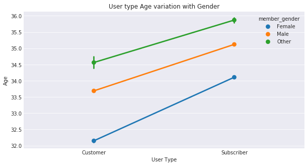

```python
fig,ax = plt.subplots(figsize=(10,5))
sns.pointplot(data=df_bike_master, x='user_type', y='member_age', hue='member_gender', ax=ax)
ax.set_title('User type Age variation with Gender')
plt.xlabel('User Type')
plt.ylabel('Age');
```

- Average age for subscribers is greater than the Customers for all genders.

```python
age_groups = np.arange(10, df_bike_master['member_age'].max()+10, 10)
age_bin = pd.cut(df_bike_master['member_age'], age_groups, right=False, include_lowest=True)
```

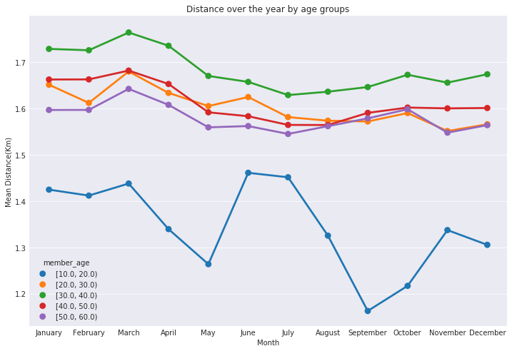

```python
fig,ax = plt.subplots(figsize=(12,8))
df = df_bike_master.groupby(['start_month',age_bin]).agg({'distance':'mean'}).reset_index()
sns.pointplot(data=df, x='start_month', y='distance', hue='member_age', ax=ax)
ax.set_title('Distance over the year by age groups')
ax.set(xlabel='Month', ylabel='Mean Distance(Km)');
```

- Mostly all the age groups show similar trends except for the teenagers(age: 10-20)
- All groups have peaks in March whereas teenagers have peak during June-July when others have the least mean distance.
- Users within the age group 30 to 40 have the highest mean distance.

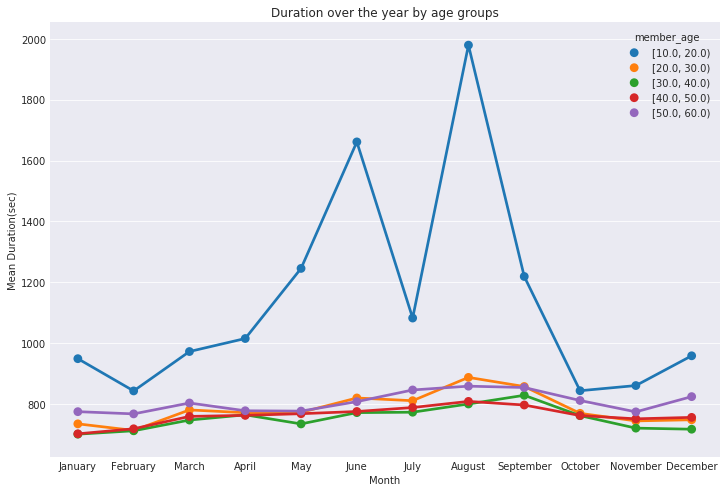

```python
fig,ax = plt.subplots(figsize=(12,8))
df = df_bike_master.groupby(['start_month',age_bin]).agg({'duration_sec':'mean'}).reset_index()
sns.pointplot(data=df, x='start_month', y='duration_sec', hue='member_age', ax=ax)
ax.set_title('Duration over the year by age groups')
ax.set(xlabel='Month', ylabel='Mean Duration(sec)');
```

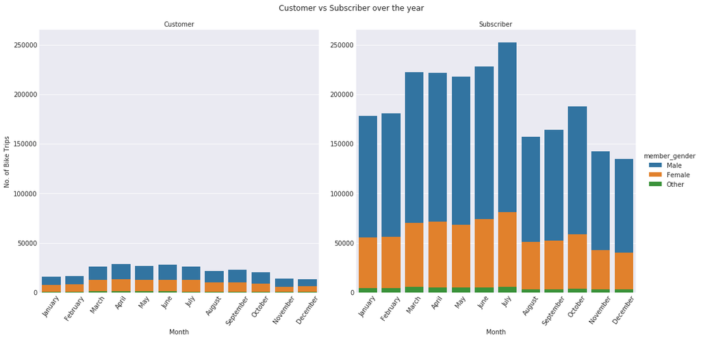

```python
g = sns.FacetGrid(data=df_bike_master, hue='member_gender', col='user_type', hue_order=['Male', 'Female', 'Other'],size=7)
g.map(sns.countplot, 'start_month')
g.set_xticklabels(rotation=55)
plt.subplots_adjust(top=0.9)
g.fig.suptitle('Customer vs Subscriber over the year')
g.set_axis_labels("Month", "No. of Bike Trips")
g.set_titles('{col_name}')
g.add_legend();
```

- Subscribers and customers both have the more number of rides in summer than winter. Subscribers have peak around July whereas customers have peak in April. Trend for subscribers and customers remain similar for all genders over the year.

### Were there any interesting or surprising interactions between features?

> - Average distance travelles by teenagers is less but the time spent is more. Changes in their trends in summer and winter are visible in the overall trend.
> - Gender does not seem to have an high impact on the trend.
> - Customer and subscriber trends vary but the data is subscriber heavy. Customer trends are not visible in overall trends.